# MSDS696_Practicum2_1b_AssessorsData_Collection_EDA_Cleaning_BemissKimberly

## Exploratory Data Analysis

The dataframe created from the manipulation of the 7 text files of assessment data (df_properties) has the following descrption (see code below).

```
Shape:  101,876 Records (rows), 83 Columns

Granularity:  Each row is unique by Account ID and Building ID ( 1 row per building on a property)
    - There are 193 Accounts with more than one building on the property.
    - 10 have more than 2 buildings on the property.

Data Types:  object, float64, int64, datetime64[ns]

Data Range:
 - Built Year:  1867 to 2021
```

```python
# Check the shape of the dataframe
df_properties.shape
```

```
(101876, 83)
```

```python
# View the first few records in the dataframe
df_properties.head()
```

|  | Account_No | Building_ID | Built_As_code | Built_As | Quality_Code | Improvement_Type_Code | Completion_Percent | Unit_Type | No_of_Fireplace | Total_Garage_SF | Walkout_Basement_Flag | Total_Porch_SF | Total_Finished_Basement_SF | Total_Unfinished_Basement_SF | Roof_Construction_Type | Built_as_SF | Exterior_Construction | Interior_Construction | No_of_Story | Roof_Material_Code | Floor_Material_Type_Code | No_of_Bedrooms | No_of_Bathrooms | Built_Year | Remodeled_Year | Length_of_Mobile_Home | Width_of_Mobile_Home | Average_Story_Height | No_Of_Unit | … |
| --- | --- | --- | --- | --- | --- | --- | --- | --- | --- | --- | --- | --- | --- | --- | --- | --- | --- | --- | --- | --- | --- | --- | --- | --- | --- | --- | --- | --- | --- | --- |
| 0 | R0000027 | 1.0 | 1 | Ranch 1 Story | Fair | 969 | 100.0 | NaN | 0 | 0 | N | 98 | 0 | 0 | Gable | 969 | Frame Siding | Drywall | 1.0 | Composition Shingle | Allowance | 2.0 | 1.0 | 1957 | 0.0 | 0.0 | 0.0 | 8.0 | 1.0 | … |
| 1 | R0000051 | 1.0 | 1 | Ranch 1 Story | Average | 1080 | 100.0 | NaN | 0 | 379 | N | 388 | 0 | 0 | Gable | 1080 | Frame Masonry Veneer | Drywall | 1.0 | Composition Shingle | Allowance | 3.0 | 1.0 | 1947 | 1960.0 | 0.0 | 0.0 | 8.0 | 1.0 | … |
| 2 | R0000174 | 1.0 | 5 | 1 1/2 Story Fin | Average | 1938 | 100.0 | NaN | 0 | 900 | N | 463 | 456 | 34 | Gable | 1938 | Frame Siding | Drywall | 2.0 | Composition Shingle | Allowance | 3.0 | 2.0 | 1935 | 1950.0 | 0.0 | 0.0 | 8.0 | 1.0 | … |
| 3 | R0000211 | 1.0 | 1 | Ranch 1 Story | Good | 2964 | 100.0 | NaN | 1 | 768 | N | 598 | 0 | 0 | Gable | 2964 | Frame Stucco | Drywall | 1.0 | Concrete Tile | Allowance | 3.0 | 2.0 | 1969 | 0.0 | 0.0 | 0.0 | 8.0 | 1.0 | … |
| 4 | R0000211 | 2.0 | 1 | Ranch 1 Story | Average | 840 | 100.0 | NaN | 0 | 0 | N | 0 | 0 | 0 | Gable | 840 | Frame Stucco | Drywall | 1.0 | Built Up Rock | Allowance | 2.0 | 1.0 | 1969 | 0.0 | 0.0 | 0.0 | 8.0 | 1.0 | … |

```python
# View the last few records in the dataframe
df_properties.tail()
```

|  | Account_No | Building_ID | Built_As_code | Built_As | Quality_Code | Improvement_Type_Code | Completion_Percent | Unit_Type | No_of_Fireplace | Total_Garage_SF | Walkout_Basement_Flag | Total_Porch_SF | Total_Finished_Basement_SF | Total_Unfinished_Basement_SF | Roof_Construction_Type | Built_as_SF | Exterior_Construction | Interior_Construction | No_of_Story | Roof_Material_Code | Floor_Material_Type_Code | No_of_Bedrooms | No_of_Bathrooms | Built_Year | Remodeled_Year | Length_of_Mobile_Home | Width_of_Mobile_Home | Average_Story_Height | No_Of_Unit | … |
| --- | --- | --- | --- | --- | --- | --- | --- | --- | --- | --- | --- | --- | --- | --- | --- | --- | --- | --- | --- | --- | --- | --- | --- | --- | --- | --- | --- | --- | --- | --- |
| 101871 | R0611792 | 1.0 | 8 | 2 Story | Average | 2809 | 100.0 | NaN | 1 | 473 | N | 60 | 0 | 1429 | Gable | 2809 | Frame Siding | Drywall | 2.0 | Composition Shingle | Allowance | 4.0 | 4.0 | 2020 | NaN | 0.0 | 0.0 | 10.0 | 1.0 | … |
| 101872 | R0611793 | 1.0 | 8 | 2 Story | Average | 2233 | 100.0 | NaN | 1 | 425 | N | 328 | 0 | 992 | Gable | 2233 | Frame Siding | Drywall | 2.0 | Composition Shingle | Allowance | 3.0 | 3.0 | 2020 | NaN | 0.0 | 0.0 | 10.0 | 1.0 | … |
| 101873 | R0611814 | 1.0 | 1 | Ranch 1 Story | Good | 3187 | 100.0 | NaN | 1 | 840 | Y | 4638 | 1553 | 1606 | Gable | 3187 | Frame Siding | Drywall | 1.0 | Wood Shake | Allowance | 4.0 | 2.0 | 1980 | 1986.0 | 0.0 | 0.0 | 8.0 | 1.0 | … |
| 101874 | R0611815 | 1.0 | 5 | 1 1/2 Story Fin | Good | 3451 | 100.0 | NaN | 1 | 495 | N | 1445 | 1747 | 301 | Hip | 3451 | Frame Siding | Drywall | 2.0 | Concrete Tile | Allowance | 3.0 | 3.0 | 1978 | 2015.0 | NaN | NaN | 8.0 | 1.0 | … |
| 101875 | R0612156 | 1.0 | 1 | Ranch 1 Story | Very Good | 3103 | 100.0 | NaN | 3 | 3347 | Y | 1617 | 2665 | 439 | Hip/Gable | 3103 | Frame Siding | Drywall | 1.0 | Concrete Tile | Allowance | 1.0 | 2.0 | 2019 | NaN | 0.0 | 0.0 | 10.0 | 1.0 | … |

```python
# View the column names in the dataframe
df_properties.columns
```

```
Index(['Account_No', 'Building_ID', 'Built_As_code', 'Built_As',
       'Quality_Code', 'Improvement_Type_Code', 'Completion_Percent',
       'Unit_Type', 'No_of_Fireplace', 'Total_Garage_SF',
       'Walkout_Basement_Flag', 'Total_Porch_SF', 'Total_Finished_Basement_SF',
       'Total_Unfinished_Basement_SF', 'Roof_Construction_Type', 'Built_as_SF',
       'Exterior_Construction', 'Interior_Construction', 'No_of_Story',
       'Roof_Material_Code', 'Floor_Material_Type_Code', 'No_of_Bedrooms',
       'No_of_Bathrooms', 'Built_Year', 'Remodeled_Year',
       'Length_of_Mobile_Home', 'Width_of_Mobile_Home', 'Average_Story_Height',
       'No_Of_Unit', 'Sprinkler_Coverage_SF', 'Condition', 'HVAC',
       'Account_Type_Code_x', 'State_Parcel_No', 'Address_No',
       'Pre_Directional_Code', 'Street_Name', 'Street_Type_Code', 'Unit_No',
       'Location_Zip_Code', 'City_Name', 'Legal_Descr', 'Township', 'Range',
       'Section', 'Quarter', 'Land_Economic_Area_Code', 'Vacant_Flag',
       'Total_Net_Acres', 'Tax_District_No', 'Neighborhood_Code',
       'Neighborhood_Extention', 'Loc_Full_Address', 'Sub_Filing_Recording_No',
       'Subdivision_Name', 'Lot_No', 'Block_No', 'Tract_No', 'Filing_No',
       'Filing_Descr', 'Owner_Name', 'Mailing_Address_Line_1',
       'Mailing_Address_Line_2', 'Mailing_City_Name', 'Mailing_State',
       'Mailing_Zip_Code', 'Actual_Value', 'Assessed_Value',
       'Valuation_Class_Code', 'Valuation_Description', 'Exempt_Flag',
       'Account_Subtype_Code', 'Valuation_Type_Code', 'Account_Type_Code_y',
       'No_of_Sales', 'Sale_Date_toMin', 'Sale_Price_Min', 'Sale_Date_toMax',
       'Sale_Price_Max', 'Min_Sale_Date', 'Sale_Price_toMin', 'Max_Sale_Date',
       'Sale_Price_toMax'],
      dtype='object')
```

```python
# View the datatypes of the different columns
df_properties.dtypes
```

```
Account_No                              object
Building_ID                            float64
Built_As_code                            int64
Built_As                                object
Quality_Code                            object
Improvement_Type_Code                    int64
Completion_Percent                     float64
Unit_Type                               object
No_of_Fireplace                          int64
Total_Garage_SF                          int64
Walkout_Basement_Flag                   object
Total_Porch_SF                           int64
Total_Finished_Basement_SF               int64
Total_Unfinished_Basement_SF             int64
Roof_Construction_Type                  object
Built_as_SF                              int64
Exterior_Construction                   object
Interior_Construction                   object
No_of_Story                            float64
Roof_Material_Code                      object
Floor_Material_Type_Code                object
No_of_Bedrooms                         float64
No_of_Bathrooms                        float64
Built_Year                               int64
Remodeled_Year                         float64
Length_of_Mobile_Home                  float64
Width_of_Mobile_Home                   float64
Average_Story_Height                   float64
No_Of_Unit                             float64
Sprinkler_Coverage_SF                  float64
Condition                               object
HVAC                                    object
Account_Type_Code_x                     object
State_Parcel_No                         object
Address_No                              object
Pre_Directional_Code                    object
Street_Name                             object
Street_Type_Code                        object
Unit_No                                 object
Location_Zip_Code                       object
```

[output cut: 29 more lines]

```
Valuation_Description                   object
Exempt_Flag                             object
Account_Subtype_Code                    object
Valuation_Type_Code                     object
Account_Type_Code_y                     object
No_of_Sales                            float64
Sale_Date_toMin                 datetime64[ns]
Sale_Price_Min                         float64
Sale_Date_toMax                 datetime64[ns]
Sale_Price_Max                         float64
Min_Sale_Date                   datetime64[ns]
Sale_Price_toMin                       float64
Max_Sale_Date                   datetime64[ns]
Sale_Price_toMax                       float64
dtype: object
```

```python
# Check the number of duplicate values
df_properties.duplicated(subset=['Account_No'], keep = 'first').sum()
```

```
204
```

```python
# Check the number of duplicate values - this dataset is unique by Account_No and Building_ID
df_properties.duplicated(subset=['Account_No','Building_ID'], keep = 'first').sum()
```

```
0
```

```python
# Use Describe to view descriptive statistics on each of the columns.
df_properties.describe(include=['object','float64','int64','datetime64[ns]'], datetime_is_numeric=True)
```

|  | Account_No | Building_ID | Built_As_code | Built_As | Quality_Code | Improvement_Type_Code | Completion_Percent | Unit_Type | No_of_Fireplace | Total_Garage_SF | Walkout_Basement_Flag | Total_Porch_SF | Total_Finished_Basement_SF | Total_Unfinished_Basement_SF | Roof_Construction_Type | Built_as_SF | Exterior_Construction | Interior_Construction | No_of_Story | Roof_Material_Code | Floor_Material_Type_Code | No_of_Bedrooms | No_of_Bathrooms | Built_Year | Remodeled_Year | Length_of_Mobile_Home | Width_of_Mobile_Home | Average_Story_Height | No_Of_Unit | … |
| --- | --- | --- | --- | --- | --- | --- | --- | --- | --- | --- | --- | --- | --- | --- | --- | --- | --- | --- | --- | --- | --- | --- | --- | --- | --- | --- | --- | --- | --- | --- |
| count | 101876 | 101876.000000 | 101876.000000 | 101876 | 101864 | 101876.000000 | 101876.000000 | 101 | 101876.000000 | 101876.000000 | 101876 | 101876.000000 | 101876.000000 | 101876.000000 | 88138 | 101876.000000 | 101864 | 101856 | 101875.000000 | 101861 | 101845 | 101843.000000 | 101842.000000 | 101876.000000 | 85657.000000 | 89077.000000 | 89077.000000 | 101873.000000 | 101875.000000 | … |
| unique | 101672 | NaN | NaN | 15 | 6 | NaN | NaN | 2 | NaN | NaN | 2 | NaN | NaN | NaN | 9 | NaN | 30 | 3 | NaN | 13 | 17 | NaN | NaN | NaN | NaN | NaN | NaN | NaN | NaN | … |
| top | R0463038 | NaN | NaN | 2 Story | Average | NaN | NaN | End | NaN | NaN | N | NaN | NaN | NaN | Gable | NaN | Frame Siding | Drywall | NaN | Composition Shingle | Allowance | NaN | NaN | NaN | NaN | NaN | NaN | NaN | NaN | … |
| freq | 4 | NaN | NaN | 67884 | 65853 | NaN | NaN | 92 | NaN | NaN | 74655 | NaN | NaN | NaN | 63812 | NaN | 87305 | 101778 | NaN | 79049 | 98749 | NaN | NaN | NaN | NaN | NaN | NaN | NaN | NaN | … |
| mean | NaN | 1.007774 | 6.362745 | NaN | NaN | 2392.202923 | 99.989546 | NaN | 0.990901 | 603.940182 | NaN | 450.750285 | 530.304350 | 681.617967 | NaN | 2392.085388 | NaN | NaN | 1.691740 | NaN | NaN | 3.320945 | 2.992672 | 1999.112195 | 162.428978 | 0.003368 | 0.002088 | 8.909417 | 1.000785 | … |
| min | NaN | 1.000000 | 1.000000 | NaN | NaN | 0.000000 | 0.000000 | NaN | 0.000000 | 0.000000 | NaN | 0.000000 | 0.000000 | -639.000000 | NaN | 0.000000 | NaN | NaN | 0.000000 | NaN | NaN | 0.000000 | 0.000000 | 1867.000000 | 0.000000 | 0.000000 | 0.000000 | -1.000000 | 0.000000 | … |
| 25% | NaN | 1.000000 | 7.000000 | NaN | NaN | 1810.000000 | 100.000000 | NaN | 1.000000 | 440.000000 | NaN | 192.000000 | 0.000000 | 124.000000 | NaN | 1810.000000 | NaN | NaN | 1.000000 | NaN | NaN | 3.000000 | 3.000000 | 1993.000000 | 0.000000 | 0.000000 | 0.000000 | 8.000000 | 1.000000 | … |
| 50% | NaN | 1.000000 | 8.000000 | NaN | NaN | 2285.000000 | 100.000000 | NaN | 1.000000 | 580.000000 | NaN | 337.000000 | 0.000000 | 513.000000 | NaN | 2285.000000 | NaN | NaN | 2.000000 | NaN | NaN | 3.000000 | 3.000000 | 1999.000000 | 0.000000 | 0.000000 | 0.000000 | 9.000000 | 1.000000 | … |
| 75% | NaN | 1.000000 | 8.000000 | NaN | NaN | 2844.000000 | 100.000000 | NaN | 1.000000 | 687.000000 | NaN | 553.000000 | 986.000000 | 1093.250000 | NaN | 2844.000000 | NaN | NaN | 2.000000 | NaN | NaN | 4.000000 | 3.000000 | 2006.000000 | 0.000000 | 0.000000 | 0.000000 | 10.000000 | 1.000000 | … |
| max | NaN | 20.000000 | 40.000000 | NaN | NaN | 16807.000000 | 100.000000 | NaN | 8.000000 | 7745.000000 | NaN | 16444.000000 | 22450.000000 | 6964.000000 | NaN | 16807.000000 | NaN | NaN | 10.000000 | NaN | NaN | 9.000000 | 18.000000 | 2021.000000 | 2020.000000 | 70.000000 | 60.000000 | 100.000000 | 20.000000 | … |
| std | NaN | 0.147081 | 3.276329 | NaN | NaN | 812.256873 | 0.919930 | NaN | 0.555729 | 264.141445 | NaN | 462.171974 | 692.394178 | 637.348965 | NaN | 812.380831 | NaN | NaN | 0.475352 | NaN | NaN | 0.834393 | 0.780292 | 12.855902 | 547.401881 | 0.439922 | 0.278312 | 1.001776 | 0.102290 | … |

##### EDA Question 1 - How many Accounts have more than one building on the property (make up the 204 duplicate rows)?

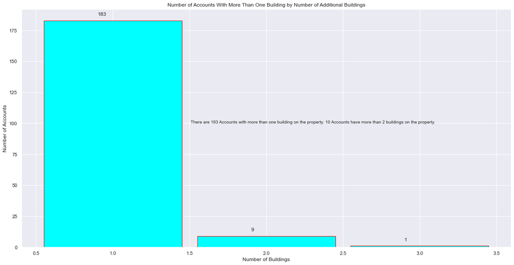

```python
# How many Accounts have more than one building on the property (make up the 204 duplicate rows)?
# Extract the duplicate records from the dataframe
account_dups = df_properties.duplicated(subset=['Account_No'], keep = 'first')
account_dups_list = df_properties[account_dups]

# Summarize the data.
account_dups_sum = account_dups_list['Account_No'].value_counts().to_frame()
account_dups_sum2 = account_dups_sum['Account_No'].value_counts().to_frame().reset_index()

# Set Figure Size
plt.figure(figsize = (20,10))

# Pass parameters to the bar function for plotting
plt.bar(account_dups_sum2['index'], account_dups_sum2['Account_No'], width= 0.9, align='center',color='cyan', edgecolor = 'red')

# Add a Title
plt.title("Number of Accounts With More Than One Building by Number of Additional Buildings")

# Add Axis Labels
plt.xlabel('Number of Buildings')
plt.ylabel('Number of Accounts')


# Text on the top of each bar
text1 = account_dups_sum2['index']
text2 = account_dups_sum2['Account_No']
for i in range(len(text1)):
    plt.text(x = text1[i]-0.1 , y = text2[i]+ 4.0, s = text2[i], size = 12)

# Add annotation
plt.annotate (" There are 193 Accounts with more than one building on the property. 10 Accounts have more than 2 buildings on the property.",
             (1.5, 100))

plt.show()
```

##### EDA Question 2 - How many New Property Improvements (buildings) and Remodels were done each year?

```python
# Aggregate Volume by Built_Year
df_properties_built = df_properties.groupby(['Built_Year']).size().to_frame('count').reset_index().drop([141],axis = 0)
# Aggregate Volume by Remodeled_Year and drop the first 2 records (non-remodels and weird entry)
df_properties_remod = df_properties.groupby(['Remodeled_Year']).size().to_frame('count').reset_index().drop([0],axis = 0)
```

```python
# View the last few records in the dataframe
df_properties_built.tail(30)
```

|  | Built_Year | count |
| --- | --- | --- |
| 111 | 1991 | 1792 |
| 112 | 1992 | 2140 |
| 113 | 1993 | 2608 |
| 114 | 1994 | 3743 |
| 115 | 1995 | 3830 |
| 116 | 1996 | 4682 |
| 117 | 1997 | 4367 |
| 118 | 1998 | 4628 |
| 119 | 1999 | 5188 |
| 120 | 2000 | 5220 |
| 121 | 2001 | 4129 |
| 122 | 2002 | 3423 |
| 123 | 2003 | 2954 |
| 124 | 2004 | 3169 |
| 125 | 2005 | 3617 |
| 126 | 2006 | 3352 |
| 127 | 2007 | 1739 |
| 128 | 2008 | 1169 |
| 129 | 2009 | 676 |
| 130 | 2010 | 747 |
| 131 | 2011 | 824 |
| 132 | 2012 | 1091 |
| 133 | 2013 | 1584 |
| 134 | 2014 | 1712 |
| 135 | 2015 | 1808 |
| 136 | 2016 | 1981 |
| 137 | 2017 | 2057 |
| 138 | 2018 | 2784 |
| 139 | 2019 | 2880 |
| 140 | 2020 | 2746 |

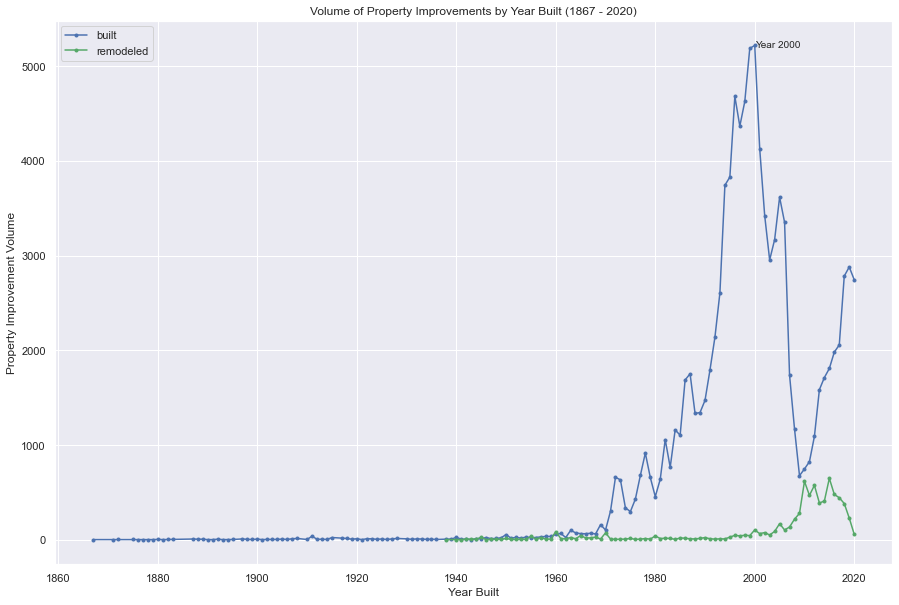

```python
## Plot Volume by Year Built and Remodels

# Set Figure labels and size
plt.figure(figsize=(15,10))
plt.title('Volume of Property Improvements by Year Built (1867 - 2020)')
plt.xlabel('Year Built')
plt.ylabel('Property Improvement Volume')

# Pass parameters to function for plotting
plt.plot(df_properties_built['Built_Year'], df_properties_built['count'], 'b.-', label = 'built')
plt.plot(df_properties_remod['Remodeled_Year'], df_properties_remod['count'], 'g.-', label = 'remodeled')

plt.annotate("Year 2000", (2000,5200))

plt.legend(loc='upper left')

plt.show()
```

##### EDA Question 3 - What are the top Cities, Subdivisions and Build Types for Single Family Residential Homes in Douglas County?

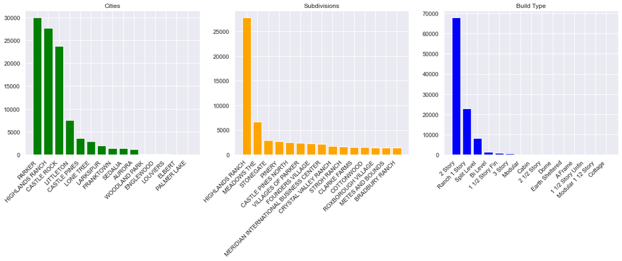

```python
# Create Summary for Cities
cities = df_properties['City_Name'].value_counts().to_frame('count').reset_index()
cities2 = cities[0:15]

# Create Summary for Subdivisions
subdiv = df_properties['Subdivision_Name'].value_counts().to_frame('count').reset_index()
subdiv2 = subdiv[0:15]

# Create Summary for Build Type
buildtype = df_properties['Built_As'].value_counts().to_frame('count').reset_index()
buildtype2 = buildtype[0:15]

# Stacking the plots (4 graphs)
fig, axs = plt.subplots(1,3, figsize=(20, 5))


# View the top cities with properties in douglas county
axs[0].bar(cities2['index'], cities2['count'], color='green')
axs[0].set_xticklabels(cities2['index'], rotation=45, ha='right')
axs[0].set_title("Cities")


# View the top subdivisions with properties in douglas county
axs[1].bar(subdiv2['index'], subdiv2['count'], color='orange')
axs[1].set_xticklabels(subdiv2['index'], rotation=45, ha='right')
axs[1].set_title("Subdivisions")

# View the top Build Types with properties in douglas county
axs[2].bar(buildtype2['index'], buildtype2['count'], color='blue')
axs[2].set_xticklabels(buildtype2['index'], rotation=45, ha='right')
axs[2].set_title("Build Type")

plt.show()
```

### Review Null and Nan Values

```python
# Check for the number of "Nan" values in each column of the dataframe
df_properties.isna().sum()
```

```
Account_No                           0
Building_ID                          0
Built_As_code                        0
Built_As                             0
Quality_Code                        12
Improvement_Type_Code                0
Completion_Percent                   0
Unit_Type                       101775
No_of_Fireplace                      0
Total_Garage_SF                      0
Walkout_Basement_Flag                0
Total_Porch_SF                       0
Total_Finished_Basement_SF           0
Total_Unfinished_Basement_SF         0
Roof_Construction_Type           13738
Built_as_SF                          0
Exterior_Construction               12
Interior_Construction               20
No_of_Story                          1
Roof_Material_Code                  15
Floor_Material_Type_Code            31
No_of_Bedrooms                      33
No_of_Bathrooms                     34
Built_Year                           0
Remodeled_Year                   16219
Length_of_Mobile_Home            12799
Width_of_Mobile_Home             12799
Average_Story_Height                 3
No_Of_Unit                           1
Sprinkler_Coverage_SF                0
Condition                           14
HVAC                                13
Account_Type_Code_x                  0
State_Parcel_No                      0
Address_No                          15
Pre_Directional_Code                 0
Street_Name                         15
Street_Type_Code                  2140
Unit_No                         101860
Location_Zip_Code                    0
```

[output cut: 29 more lines]

```
Valuation_Description               47
Exempt_Flag                         47
Account_Subtype_Code                47
Valuation_Type_Code                 47
Account_Type_Code_y                 47
No_of_Sales                        288
Sale_Date_toMin                    288
Sale_Price_Min                     288
Sale_Date_toMax                    288
Sale_Price_Max                     288
Min_Sale_Date                      288
Sale_Price_toMin                   288
Max_Sale_Date                      288
Sale_Price_toMax                   288
dtype: int64
```

```python
# Review the information on the dataframe (columns, non-null count, data types, index range, )
df_properties.info()
```

```
<class 'pandas.core.frame.DataFrame'>
Int64Index: 101876 entries, 0 to 101875
Data columns (total 83 columns):
 #   Column                        Non-Null Count   Dtype
---  ------                        --------------   -----
 0   Account_No                    101876 non-null  object
 1   Building_ID                   101876 non-null  float64
 2   Built_As_code                 101876 non-null  int64
 3   Built_As                      101876 non-null  object
 4   Quality_Code                  101864 non-null  object
 5   Improvement_Type_Code         101876 non-null  int64
 6   Completion_Percent            101876 non-null  float64
 7   Unit_Type                     101 non-null     object
 8   No_of_Fireplace               101876 non-null  int64
 9   Total_Garage_SF               101876 non-null  int64
```

[output cut: 75 more lines]

##### Create an Index Column

```python
# create a column from index value
df_properties.reset_index(inplace=True)
df_properties.head()
```

|  | index | Account_No | Building_ID | Built_As_code | Built_As | Quality_Code | Improvement_Type_Code | Completion_Percent | Unit_Type | No_of_Fireplace | Total_Garage_SF | Walkout_Basement_Flag | Total_Porch_SF | Total_Finished_Basement_SF | Total_Unfinished_Basement_SF | Roof_Construction_Type | Built_as_SF | Exterior_Construction | Interior_Construction | No_of_Story | Roof_Material_Code | Floor_Material_Type_Code | No_of_Bedrooms | No_of_Bathrooms | Built_Year | Remodeled_Year | Length_of_Mobile_Home | Width_of_Mobile_Home | Average_Story_Height | … |
| --- | --- | --- | --- | --- | --- | --- | --- | --- | --- | --- | --- | --- | --- | --- | --- | --- | --- | --- | --- | --- | --- | --- | --- | --- | --- | --- | --- | --- | --- | --- |
| 0 | 0 | R0000027 | 1.0 | 1 | Ranch 1 Story | Fair | 969 | 100.0 | NaN | 0 | 0 | N | 98 | 0 | 0 | Gable | 969 | Frame Siding | Drywall | 1.0 | Composition Shingle | Allowance | 2.0 | 1.0 | 1957 | 0.0 | 0.0 | 0.0 | 8.0 | … |
| 1 | 1 | R0000051 | 1.0 | 1 | Ranch 1 Story | Average | 1080 | 100.0 | NaN | 0 | 379 | N | 388 | 0 | 0 | Gable | 1080 | Frame Masonry Veneer | Drywall | 1.0 | Composition Shingle | Allowance | 3.0 | 1.0 | 1947 | 1960.0 | 0.0 | 0.0 | 8.0 | … |
| 2 | 2 | R0000174 | 1.0 | 5 | 1 1/2 Story Fin | Average | 1938 | 100.0 | NaN | 0 | 900 | N | 463 | 456 | 34 | Gable | 1938 | Frame Siding | Drywall | 2.0 | Composition Shingle | Allowance | 3.0 | 2.0 | 1935 | 1950.0 | 0.0 | 0.0 | 8.0 | … |
| 3 | 3 | R0000211 | 1.0 | 1 | Ranch 1 Story | Good | 2964 | 100.0 | NaN | 1 | 768 | N | 598 | 0 | 0 | Gable | 2964 | Frame Stucco | Drywall | 1.0 | Concrete Tile | Allowance | 3.0 | 2.0 | 1969 | 0.0 | 0.0 | 0.0 | 8.0 | … |
| 4 | 4 | R0000211 | 2.0 | 1 | Ranch 1 Story | Average | 840 | 100.0 | NaN | 0 | 0 | N | 0 | 0 | 0 | Gable | 840 | Frame Stucco | Drywall | 1.0 | Built Up Rock | Allowance | 2.0 | 1.0 | 1969 | 0.0 | 0.0 | 0.0 | 8.0 | … |

```python
# View the shape of the dataframe
df_properties.shape
```

```
(101876, 84)
```

```python
# View Description of dataframe
df_properties.describe(include=['object','float64','int64','datetime64[ns]'],datetime_is_numeric=True)
```

|  | index | Account_No | Building_ID | Built_As_code | Built_As | Quality_Code | Improvement_Type_Code | Completion_Percent | Unit_Type | No_of_Fireplace | Total_Garage_SF | Walkout_Basement_Flag | Total_Porch_SF | Total_Finished_Basement_SF | Total_Unfinished_Basement_SF | Roof_Construction_Type | Built_as_SF | Exterior_Construction | Interior_Construction | No_of_Story | Roof_Material_Code | Floor_Material_Type_Code | No_of_Bedrooms | No_of_Bathrooms | Built_Year | Remodeled_Year | Length_of_Mobile_Home | Width_of_Mobile_Home | Average_Story_Height | … |
| --- | --- | --- | --- | --- | --- | --- | --- | --- | --- | --- | --- | --- | --- | --- | --- | --- | --- | --- | --- | --- | --- | --- | --- | --- | --- | --- | --- | --- | --- | --- |
| count | 101876.000000 | 101876 | 101876.000000 | 101876.000000 | 101876 | 101864 | 101876.000000 | 101876.000000 | 101 | 101876.000000 | 101876.000000 | 101876 | 101876.000000 | 101876.000000 | 101876.000000 | 88138 | 101876.000000 | 101864 | 101856 | 101875.000000 | 101861 | 101845 | 101843.000000 | 101842.000000 | 101876.000000 | 85657.000000 | 89077.000000 | 89077.000000 | 101873.000000 | … |
| unique | NaN | 101672 | NaN | NaN | 15 | 6 | NaN | NaN | 2 | NaN | NaN | 2 | NaN | NaN | NaN | 9 | NaN | 30 | 3 | NaN | 13 | 17 | NaN | NaN | NaN | NaN | NaN | NaN | NaN | … |
| top | NaN | R0463038 | NaN | NaN | 2 Story | Average | NaN | NaN | End | NaN | NaN | N | NaN | NaN | NaN | Gable | NaN | Frame Siding | Drywall | NaN | Composition Shingle | Allowance | NaN | NaN | NaN | NaN | NaN | NaN | NaN | … |
| freq | NaN | 4 | NaN | NaN | 67884 | 65853 | NaN | NaN | 92 | NaN | NaN | 74655 | NaN | NaN | NaN | 63812 | NaN | 87305 | 101778 | NaN | 79049 | 98749 | NaN | NaN | NaN | NaN | NaN | NaN | NaN | … |
| mean | 50937.500000 | NaN | 1.007774 | 6.362745 | NaN | NaN | 2392.202923 | 99.989546 | NaN | 0.990901 | 603.940182 | NaN | 450.750285 | 530.304350 | 681.617967 | NaN | 2392.085388 | NaN | NaN | 1.691740 | NaN | NaN | 3.320945 | 2.992672 | 1999.112195 | 162.428978 | 0.003368 | 0.002088 | 8.909417 | … |
| min | 0.000000 | NaN | 1.000000 | 1.000000 | NaN | NaN | 0.000000 | 0.000000 | NaN | 0.000000 | 0.000000 | NaN | 0.000000 | 0.000000 | -639.000000 | NaN | 0.000000 | NaN | NaN | 0.000000 | NaN | NaN | 0.000000 | 0.000000 | 1867.000000 | 0.000000 | 0.000000 | 0.000000 | -1.000000 | … |
| 25% | 25468.750000 | NaN | 1.000000 | 7.000000 | NaN | NaN | 1810.000000 | 100.000000 | NaN | 1.000000 | 440.000000 | NaN | 192.000000 | 0.000000 | 124.000000 | NaN | 1810.000000 | NaN | NaN | 1.000000 | NaN | NaN | 3.000000 | 3.000000 | 1993.000000 | 0.000000 | 0.000000 | 0.000000 | 8.000000 | … |
| 50% | 50937.500000 | NaN | 1.000000 | 8.000000 | NaN | NaN | 2285.000000 | 100.000000 | NaN | 1.000000 | 580.000000 | NaN | 337.000000 | 0.000000 | 513.000000 | NaN | 2285.000000 | NaN | NaN | 2.000000 | NaN | NaN | 3.000000 | 3.000000 | 1999.000000 | 0.000000 | 0.000000 | 0.000000 | 9.000000 | … |
| 75% | 76406.250000 | NaN | 1.000000 | 8.000000 | NaN | NaN | 2844.000000 | 100.000000 | NaN | 1.000000 | 687.000000 | NaN | 553.000000 | 986.000000 | 1093.250000 | NaN | 2844.000000 | NaN | NaN | 2.000000 | NaN | NaN | 4.000000 | 3.000000 | 2006.000000 | 0.000000 | 0.000000 | 0.000000 | 10.000000 | … |
| max | 101875.000000 | NaN | 20.000000 | 40.000000 | NaN | NaN | 16807.000000 | 100.000000 | NaN | 8.000000 | 7745.000000 | NaN | 16444.000000 | 22450.000000 | 6964.000000 | NaN | 16807.000000 | NaN | NaN | 10.000000 | NaN | NaN | 9.000000 | 18.000000 | 2021.000000 | 2020.000000 | 70.000000 | 60.000000 | 100.000000 | … |
| std | 29409.212349 | NaN | 0.147081 | 3.276329 | NaN | NaN | 812.256873 | 0.919930 | NaN | 0.555729 | 264.141445 | NaN | 462.171974 | 692.394178 | 637.348965 | NaN | 812.380831 | NaN | NaN | 0.475352 | NaN | NaN | 0.834393 | 0.780292 | 12.855902 | 547.401881 | 0.439922 | 0.278312 | 1.001776 | … |

### Replace NaN values in columns

###### Unit Type

```python
# View the records for "Unit Type" to determine if the column needs to be retained.
# This term refers to the way Condominium or Townhouse properties are typically constructed in groups
# where some of the walls are common or shared. A unit’s location in the overall structure can influence
# its market value, based on whether it is an interior or end unit
df_unit_type = df_properties.groupby(['Built_As','No_Of_Unit','Unit_Type']).size().to_frame('count')
df_unit_type
```

| Built_As | No_Of_Unit | Unit_Type | count |
| --- | --- | --- | --- |
| 2 Story | 1.0 | End | 32 |
|  |  | Inside | 6 |
| Ranch 1 Story | 1.0 | End | 60 |
|  |  | Inside | 3 |

```python
# Fill any "Nan" values with descriptive value "Individual"
df_properties['Unit_Type'].fillna(value='Individual', inplace=True)
```

###### Quality Code

```python
# View the records for "Quality Code"
df_properties['Quality_Code'].value_counts()
```

```
Average      65853
Good         27172
Very Good     7217
Excellent     1244
Fair           330
Low             48
Name: Quality_Code, dtype: int64
```

```python
# View Quality Code N/A built as values
df_qual_code = df_properties[(df_properties['Quality_Code'].isna())].groupby(['Built_As']).size().to_frame('count')
df_qual_code
```

| Built_As | count |
| --- | --- |
| 2 Story | 8 |
| Ranch 1 Story | 4 |

```python
# Fill any "Nan" values with descriptive value "Not Rated"
df_properties['Quality_Code'].fillna(value='Not Rated', inplace=True)
```

###### Construction Materials Variables

```python
# View Roof Construction N/A built as values
df_roof = df_properties[(df_properties['Roof_Construction_Type'].isna())].groupby(['Built_As']).size().to_frame('count')
df_roof
```

| Built_As | count |
| --- | --- |
| 1 1/2 Story Fin | 186 |
| 1 1/2 Story Unfin | 1 |
| 2 Story | 8357 |
| Bi Level | 341 |
| Cabin | 10 |
| Dome | 6 |
| Earth Sheltered | 4 |
| Modular | 5 |
| Ranch 1 Story | 2698 |
| Split Level | 2130 |

```python
# Fill any "Nan" values with descriptive value "Unknown"
df_properties['Roof_Construction_Type'].fillna(value='Unknown', inplace=True)
```

```python
# Fill any "Nan" values with descriptive value "Unknown"
df_properties['Exterior_Construction'].fillna(value='Unknown', inplace=True)
df_properties['Interior_Construction'].fillna(value='Unknown', inplace=True)
df_properties['Condition'].fillna(value='Unknown', inplace=True)
df_properties['HVAC'].fillna(value='Unknown', inplace=True)
df_properties['Roof_Material_Code'].fillna(value='Unknown', inplace=True)
df_properties['Floor_Material_Type_Code'].fillna(value='Unknown', inplace=True)
```

###### Completion Percentage

```python
# View the values and counts for completion percent - what are the homes not 100% complete?
df_properties['Completion_Percent'].value_counts()
```

```
100.0    101861
50.0          7
0.0           6
75.0          1
10.0          1
Name: Completion_Percent, dtype: int64
```

```python
# Create a new dataframe grouped by 2 columns with the counts of records
df_comp_perc = df_properties.groupby(['Built_As','Completion_Percent']).size().to_frame('count')
df_comp_perc
```

| Built_As | Completion_Percent | count |
| --- | --- | --- |
| 1 1/2 Story Fin | 100.0 | 910 |
| 1 1/2 Story Unfin | 100.0 | 5 |
| 2 1/2 Story | 100.0 | 35 |
| 2 Story | 0.0 | 3 |
|  | 10.0 | 1 |
|  | 50.0 | 3 |
|  | 75.0 | 1 |
|  | 100.0 | 67876 |
| 3 Story | 100.0 | 493 |
| A Frame | 100.0 | 11 |
| Bi Level | 50.0 | 1 |
|  | 100.0 | 1298 |
| Cabin | 100.0 | 115 |
| Cottage | 100.0 | 1 |
| Dome | 100.0 | 18 |
| Earth Sheltered | 100.0 | 17 |
| Modular | 100.0 | 156 |
| Modular 1 12 Story | 100.0 | 1 |
| Ranch 1 Story | 0.0 | 3 |
|  | 50.0 | 2 |
|  | 100.0 | 22774 |
| Split Level | 50.0 | 1 |
|  | 100.0 | 8151 |

```python
# View records with completion % less than 100%
df_comp_perc_plot = df_properties[(df_properties['Completion_Percent'] < 100.0)]
df_comp_perc_plot
```

|  | index | Account_No | Building_ID | Built_As_code | Built_As | Quality_Code | Improvement_Type_Code | Completion_Percent | Unit_Type | No_of_Fireplace | Total_Garage_SF | Walkout_Basement_Flag | Total_Porch_SF | Total_Finished_Basement_SF | Total_Unfinished_Basement_SF | Roof_Construction_Type | Built_as_SF | Exterior_Construction | Interior_Construction | No_of_Story | Roof_Material_Code | Floor_Material_Type_Code | No_of_Bedrooms | No_of_Bathrooms | Built_Year | Remodeled_Year | Length_of_Mobile_Home | Width_of_Mobile_Home | Average_Story_Height | … |
| --- | --- | --- | --- | --- | --- | --- | --- | --- | --- | --- | --- | --- | --- | --- | --- | --- | --- | --- | --- | --- | --- | --- | --- | --- | --- | --- | --- | --- | --- | --- |
| 11134 | 11134 | R0222308 | 1.0 | 7 | Split Level | Average | 2118 | 50.0 | Individual | 0 | 624 | N | 120 | 0 | 0 | Gable | 2118 | Frame Siding | Drywall | 1.0 | Composition Shingle | Allowance | 3.0 | 2.0 | 1983 | 0.0 | 0.0 | 0.0 | 9.0 | … |
| 33566 | 33566 | R0372294 | 1.0 | 8 | 2 Story | Very Good | 4546 | 75.0 | Individual | 1 | 777 | N | 0 | 0 | 2618 | Hip | 4546 | Frame Stone Veneer | Drywall | 2.0 | Concrete Tile | Allowance | 4.0 | 4.0 | 2000 | 0.0 | 0.0 | 0.0 | 10.0 | … |
| 33567 | 33567 | R0372294 | 2.0 | 8 | 2 Story | Excellent | 15073 | 50.0 | Individual | 2 | 4746 | Y | 16444 | 2670 | 1235 | Hip | 15073 | Frame Stone Veneer | Drywall | 2.0 | Slate | Allowance | 4.0 | 9.0 | 1999 | NaN | 0.0 | 0.0 | 10.0 | … |
| 84579 | 84579 | R0467786 | 1.0 | 8 | 2 Story | Not Rated | 3803 | 0.0 | Individual | 1 | 714 | N | 357 | 1459 | 442 | Unknown | 0 | Unknown | Unknown | 0.0 | Unknown | Unknown | NaN | NaN | 2020 | NaN | 0.0 | 0.0 | 8.0 | … |
| 99976 | 99976 | R0498558 | 1.0 | 8 | 2 Story | Not Rated | 0 | 10.0 | Individual | 0 | 486 | N | 121 | 0 | 1137 | Unknown | 0 | Unknown | Unknown | NaN | Unknown | Unknown | NaN | NaN | 2020 | NaN | 0.0 | 0.0 | 10.0 | … |
| 100210 | 100210 | R0499104 | 1.0 | 1 | Ranch 1 Story | Not Rated | 1966 | 0.0 | Individual | 1 | 492 | N | 268 | 0 | 1966 | Unknown | 0 | Unknown | Unknown | 0.0 | Unknown | Unknown | NaN | NaN | 2020 | NaN | 0.0 | 0.0 | 8.0 | … |
| 100856 | 100856 | R0600713 | 1.0 | 8 | 2 Story | Not Rated | 3270 | 0.0 | Individual | 1 | 707 | N | 275 | 0 | 1422 | Unknown | 0 | Unknown | Unknown | 0.0 | Unknown | Unknown | NaN | NaN | 2020 | NaN | 0.0 | 0.0 | 8.0 | … |
| 100961 | 100961 | R0601073 | 1.0 | 1 | Ranch 1 Story | Not Rated | 2493 | 0.0 | Individual | 1 | 696 | Y | 360 | 1 | 2493 | Unknown | 0 | Unknown | Unknown | 0.0 | Unknown | Unknown | NaN | NaN | 2020 | NaN | 0.0 | 0.0 | 8.0 | … |
| 101187 | 101187 | R0601929 | 1.0 | 8 | 2 Story | Average | 3899 | 50.0 | Individual | 1 | 803 | Y | 587 | 0 | 2424 | Gable | 3899 | Frame Siding | Drywall | 2.0 | Composition Shingle | Allowance | 4.0 | 4.0 | 2020 | NaN | 0.0 | 0.0 | 10.0 | … |
| 101440 | 101440 | R0602467 | 1.0 | 1 | Ranch 1 Story | Average | 1540 | 50.0 | Individual | 1 | 511 | N | 94 | 0 | 1540 | Hip/Gable | 1540 | Frame Siding | Drywall | 0.0 | Composition Shingle | Unknown | NaN | NaN | 2020 | NaN | 0.0 | 0.0 | 8.0 | … |
| 101506 | 101506 | R0603045 | 1.0 | 2 | Bi Level | Good | 4919 | 50.0 | Individual | 3 | 1133 | N | 1346 | 0 | 2525 | Gable | 4919 | Frame Siding | Unknown | 2.0 | Composition Shingle | Unknown | NaN | NaN | 2020 | NaN | 0.0 | 0.0 | 10.0 | … |
| 101532 | 101532 | R0603638 | 2.0 | 8 | 2 Story | Excellent | 2406 | 0.0 | Individual | 1 | 572 | N | 5482 | 2536 | 517 | Gable | 2406 | Frame Stucco | Drywall | 1.0 | Concrete Tile | Allowance | 1.0 | 2.0 | 2020 | NaN | 0.0 | 0.0 | 9.0 | … |
| 101585 | 101585 | R0603783 | 1.0 | 1 | Ranch 1 Story | Average | 1971 | 50.0 | Individual | 1 | 520 | N | 188 | 0 | 1972 | Gable | 1971 | Frame Siding | Drywall | 1.0 | Composition Shingle | Allowance | 3.0 | 3.0 | 2020 | NaN | 0.0 | 0.0 | 10.0 | … |
| 101723 | 101723 | R0605146 | 1.0 | 8 | 2 Story | Not Rated | 4081 | 50.0 | Individual | 1 | 726 | N | 502 | 0 | 1872 | Gable | 4081 | Unknown | Unknown | 2.0 | Composition Shingle | Allowance | 5.0 | 6.0 | 2020 | NaN | 0.0 | 0.0 | 10.0 | … |
| 101791 | 101791 | R0606244 | 1.0 | 1 | Ranch 1 Story | Average | 1574 | 0.0 | Individual | 0 | 420 | N | 138 | 0 | 1574 | Unknown | 1574 | Frame Siding | Drywall | 0.0 | Composition Shingle | Allowance | NaN | NaN | 2020 | NaN | 0.0 | 0.0 | 8.0 | … |

```python
# Create an indicator for "Complete" or "Incomplete"
df_properties['Complete'] = np.where(df_properties['Completion_Percent']< 100.0, 0, 1)
df_properties.head(2)
```

|  | index | Account_No | Building_ID | Built_As_code | Built_As | Quality_Code | Improvement_Type_Code | Completion_Percent | Unit_Type | No_of_Fireplace | Total_Garage_SF | Walkout_Basement_Flag | Total_Porch_SF | Total_Finished_Basement_SF | Total_Unfinished_Basement_SF | Roof_Construction_Type | Built_as_SF | Exterior_Construction | Interior_Construction | No_of_Story | Roof_Material_Code | Floor_Material_Type_Code | No_of_Bedrooms | No_of_Bathrooms | Built_Year | Remodeled_Year | Length_of_Mobile_Home | Width_of_Mobile_Home | Average_Story_Height | … |
| --- | --- | --- | --- | --- | --- | --- | --- | --- | --- | --- | --- | --- | --- | --- | --- | --- | --- | --- | --- | --- | --- | --- | --- | --- | --- | --- | --- | --- | --- | --- |
| 0 | 0 | R0000027 | 1.0 | 1 | Ranch 1 Story | Fair | 969 | 100.0 | Individual | 0 | 0 | N | 98 | 0 | 0 | Gable | 969 | Frame Siding | Drywall | 1.0 | Composition Shingle | Allowance | 2.0 | 1.0 | 1957 | 0.0 | 0.0 | 0.0 | 8.0 | … |
| 1 | 1 | R0000051 | 1.0 | 1 | Ranch 1 Story | Average | 1080 | 100.0 | Individual | 0 | 379 | N | 388 | 0 | 0 | Gable | 1080 | Frame Masonry Veneer | Drywall | 1.0 | Composition Shingle | Allowance | 3.0 | 1.0 | 1947 | 1960.0 | 0.0 | 0.0 | 8.0 | … |

###### Number of Stories

```python
# View missing No of Stories information
df_stories = df_properties[(df_properties['No_of_Story'].isna())]
df_stories
```

|  | index | Account_No | Building_ID | Built_As_code | Built_As | Quality_Code | Improvement_Type_Code | Completion_Percent | Unit_Type | No_of_Fireplace | Total_Garage_SF | Walkout_Basement_Flag | Total_Porch_SF | Total_Finished_Basement_SF | Total_Unfinished_Basement_SF | Roof_Construction_Type | Built_as_SF | Exterior_Construction | Interior_Construction | No_of_Story | Roof_Material_Code | Floor_Material_Type_Code | No_of_Bedrooms | No_of_Bathrooms | Built_Year | Remodeled_Year | Length_of_Mobile_Home | Width_of_Mobile_Home | Average_Story_Height | … |
| --- | --- | --- | --- | --- | --- | --- | --- | --- | --- | --- | --- | --- | --- | --- | --- | --- | --- | --- | --- | --- | --- | --- | --- | --- | --- | --- | --- | --- | --- | --- |
| 99976 | 99976 | R0498558 | 1.0 | 8 | 2 Story | Not Rated | 0 | 10.0 | Individual | 0 | 486 | N | 121 | 0 | 1137 | Unknown | 0 | Unknown | Unknown | NaN | Unknown | Unknown | NaN | NaN | 2020 | NaN | 0.0 | 0.0 | 10.0 | … |

```python
# Set missign data to "2" for stories based on built as type
df_properties['No_of_Story'].fillna(value=2, inplace=True)
```

###### Number of Units

```python
# View missing No of Stories information
df_units = df_properties[(df_properties['No_Of_Unit'].isna())]
df_units
```

|  | index | Account_No | Building_ID | Built_As_code | Built_As | Quality_Code | Improvement_Type_Code | Completion_Percent | Unit_Type | No_of_Fireplace | Total_Garage_SF | Walkout_Basement_Flag | Total_Porch_SF | Total_Finished_Basement_SF | Total_Unfinished_Basement_SF | Roof_Construction_Type | Built_as_SF | Exterior_Construction | Interior_Construction | No_of_Story | Roof_Material_Code | Floor_Material_Type_Code | No_of_Bedrooms | No_of_Bathrooms | Built_Year | Remodeled_Year | Length_of_Mobile_Home | Width_of_Mobile_Home | Average_Story_Height | … |
| --- | --- | --- | --- | --- | --- | --- | --- | --- | --- | --- | --- | --- | --- | --- | --- | --- | --- | --- | --- | --- | --- | --- | --- | --- | --- | --- | --- | --- | --- | --- |
| 99976 | 99976 | R0498558 | 1.0 | 8 | 2 Story | Not Rated | 0 | 10.0 | Individual | 0 | 486 | N | 121 | 0 | 1137 | Unknown | 0 | Unknown | Unknown | 2.0 | Unknown | Unknown | NaN | NaN | 2020 | NaN | 0.0 | 0.0 | 10.0 | … |

```python
# Set missign data to "1" for units based on built as type
df_properties['No_Of_Unit'].fillna(value=1, inplace=True)
```

###### Number of Bedrooms

```python
# View No of Bedroom N/A value
df_bedroom_nas = df_properties[(df_properties['No_of_Bedrooms'].isna())].groupby(['Built_Year','Built_As']).size().to_frame('count')
df_bedroom_nas
```

| Built_Year | Built_As | count |
| --- | --- | --- |
| 2016 | 2 Story | 1 |
| 2019 | 2 Story | 1 |
| 2020 | 2 Story | 15 |
|  | 3 Story | 5 |
|  | Bi Level | 1 |
|  | Ranch 1 Story | 9 |
| 2021 | 2 Story | 1 |

```python
# View the records
df_nas1 = df_properties[(df_properties['No_of_Bedrooms'].isna())]
df_nas1
```

|  | index | Account_No | Building_ID | Built_As_code | Built_As | Quality_Code | Improvement_Type_Code | Completion_Percent | Unit_Type | No_of_Fireplace | Total_Garage_SF | Walkout_Basement_Flag | Total_Porch_SF | Total_Finished_Basement_SF | Total_Unfinished_Basement_SF | Roof_Construction_Type | Built_as_SF | Exterior_Construction | Interior_Construction | No_of_Story | Roof_Material_Code | Floor_Material_Type_Code | No_of_Bedrooms | No_of_Bathrooms | Built_Year | Remodeled_Year | Length_of_Mobile_Home | Width_of_Mobile_Home | Average_Story_Height | … |
| --- | --- | --- | --- | --- | --- | --- | --- | --- | --- | --- | --- | --- | --- | --- | --- | --- | --- | --- | --- | --- | --- | --- | --- | --- | --- | --- | --- | --- | --- | --- |
| 76707 | 76707 | R0448680 | 1.0 | 1 | Ranch 1 Story | Good | 3158 | 100.0 | Individual | 0 | 707 | N | 265 | 0 | 1390 | Unknown | 3158 | Unknown | Unknown | 0.0 | Unknown | Unknown | NaN | NaN | 2020 | NaN | 0.0 | 0.0 | 8.0 | … |
| 84579 | 84579 | R0467786 | 1.0 | 8 | 2 Story | Not Rated | 3803 | 0.0 | Individual | 1 | 714 | N | 357 | 1459 | 442 | Unknown | 0 | Unknown | Unknown | 0.0 | Unknown | Unknown | NaN | NaN | 2020 | NaN | 0.0 | 0.0 | 8.0 | … |
| 86252 | 86252 | R0471422 | 1.0 | 8 | 2 Story | Average | 2265 | 100.0 | Individual | 0 | 420 | N | 395 | 0 | 0 | Gable | 2265 | Frame Siding | Drywall | 2.0 | Composition Shingle | Allowance | NaN | NaN | 2020 | NaN | 0.0 | 0.0 | 10.0 | … |
| 95722 | 95722 | R0491384 | 1.0 | 8 | 2 Story | Average | 3766 | 100.0 | Individual | 1 | 737 | N | 450 | 0 | 1913 | Hip/Gable | 3766 | Frame Siding | Drywall | 2.0 | Composition Shingle | Allowance | NaN | NaN | 2020 | NaN | 0.0 | 0.0 | 10.0 | … |
| 95742 | 95742 | R0491409 | 1.0 | 1 | Ranch 1 Story | Good | 2524 | 100.0 | Individual | 1 | 912 | Y | 269 | 0 | 2525 | Gable | 2524 | Frame Siding | Drywall | 1.0 | Composition Shingle | Allowance | NaN | NaN | 2020 | NaN | 0.0 | 0.0 | 10.0 | … |
| 98311 | 98311 | R0495320 | 1.0 | 25 | 3 Story | Average | 2201 | 100.0 | Individual | 1 | 728 | N | 400 | 0 | 0 | Gable | 2201 | Frame Siding | Drywall | 3.0 | Composition Shingle | Allowance | NaN | NaN | 2020 | NaN | 0.0 | 0.0 | 10.0 | … |
| 98312 | 98312 | R0495321 | 1.0 | 25 | 3 Story | Average | 2522 | 100.0 | Individual | 1 | 648 | N | 497 | 0 | 0 | Gable | 2522 | Frame Siding | Drywall | 3.0 | Composition Shingle | Allowance | NaN | NaN | 2020 | NaN | 0.0 | 0.0 | 10.0 | … |
| 98560 | 98560 | R0495646 | 1.0 | 1 | Ranch 1 Story | Not Rated | 2340 | 100.0 | Individual | 0 | 504 | N | 226 | 0 | 1732 | Unknown | 2340 | Unknown | Unknown | 0.0 | Unknown | Unknown | NaN | NaN | 2020 | NaN | 0.0 | 0.0 | 8.0 | … |
| 98816 | 98816 | R0495965 | 1.0 | 1 | Ranch 1 Story | Average | 1797 | 100.0 | Individual | 1 | 464 | N | 358 | 1519 | 273 | Gable | 1797 | Frame Siding | Drywall | 0.0 | Concrete Tile | Allowance | NaN | NaN | 2020 | NaN | 0.0 | 0.0 | 8.0 | … |
| 99544 | 99544 | R0497152 | 1.0 | 8 | 2 Story | Average | 2372 | 100.0 | Individual | 0 | 460 | N | 129 | 0 | 1028 | Unknown | 2372 | Frame Siding | Drywall | 2.0 | Composition Shingle | Allowance | NaN | NaN | 2020 | NaN | 0.0 | 0.0 | 10.0 | … |
| 99843 | 99843 | R0498269 | 1.0 | 8 | 2 Story | Very Good | 5364 | 100.0 | Individual | 1 | 1550 | Y | 2047 | 2631 | 612 | Hip | 5364 | Frame Stucco | Drywall | 2.0 | Composition Shingle | Ceramic Tile | NaN | NaN | 2016 | NaN | 0.0 | 0.0 | 8.0 | … |
| 99976 | 99976 | R0498558 | 1.0 | 8 | 2 Story | Not Rated | 0 | 10.0 | Individual | 0 | 486 | N | 121 | 0 | 1137 | Unknown | 0 | Unknown | Unknown | 2.0 | Unknown | Unknown | NaN | NaN | 2020 | NaN | 0.0 | 0.0 | 10.0 | … |
| 100054 | 100054 | R0498692 | 1.0 | 8 | 2 Story | Average | 2135 | 100.0 | Individual | 0 | 472 | N | 177 | 0 | 845 | Hip | 2135 | Frame Siding | Drywall | 0.0 | Composition Shingle | Allowance | NaN | NaN | 2020 | NaN | 0.0 | 0.0 | 8.0 | … |
| 100210 | 100210 | R0499104 | 1.0 | 1 | Ranch 1 Story | Not Rated | 1966 | 0.0 | Individual | 1 | 492 | N | 268 | 0 | 1966 | Unknown | 0 | Unknown | Unknown | 0.0 | Unknown | Unknown | NaN | NaN | 2020 | NaN | 0.0 | 0.0 | 8.0 | … |
| 100745 | 100745 | R0600471 | 1.0 | 25 | 3 Story | Average | 1921 | 100.0 | Individual | 0 | 474 | N | 542 | 0 | 0 | Shed | 1921 | Frame Siding | Drywall | 3.0 | Composition Shingle | Allowance | NaN | NaN | 2020 | NaN | 0.0 | 0.0 | 10.0 | … |
| 100746 | 100746 | R0600472 | 1.0 | 25 | 3 Story | Average | 2071 | 100.0 | Individual | 0 | 495 | N | 662 | 0 | 0 | Shed | 2071 | Frame Siding | Drywall | 3.0 | Composition Shingle | Allowance | NaN | NaN | 2020 | NaN | 0.0 | 0.0 | 10.0 | … |
| 100749 | 100749 | R0600475 | 1.0 | 25 | 3 Story | Average | 2071 | 100.0 | Individual | 0 | 495 | N | 662 | 0 | 0 | Shed | 2071 | Frame Siding | Drywall | 3.0 | Composition Shingle | Allowance | NaN | NaN | 2020 | NaN | 0.0 | 0.0 | 10.0 | … |
| 100856 | 100856 | R0600713 | 1.0 | 8 | 2 Story | Not Rated | 3270 | 0.0 | Individual | 1 | 707 | N | 275 | 0 | 1422 | Unknown | 0 | Unknown | Unknown | 0.0 | Unknown | Unknown | NaN | NaN | 2020 | NaN | 0.0 | 0.0 | 8.0 | … |
| 100873 | 100873 | R0600763 | 1.0 | 1 | Ranch 1 Story | Average | 1783 | 100.0 | Individual | 0 | 483 | N | 49 | 0 | 0 | Gable | 1783 | Frame Siding | Drywall | 1.0 | Composition Shingle | Allowance | NaN | NaN | 2020 | NaN | 0.0 | 0.0 | 9.0 | … |
| 100875 | 100875 | R0600777 | 1.0 | 8 | 2 Story | Average | 2265 | 100.0 | Individual | 0 | 420 | N | 395 | 0 | 0 | Hip | 2265 | Frame Siding | Drywall | 2.0 | Composition Shingle | Allowance | NaN | NaN | 2020 | NaN | 0.0 | 0.0 | 10.0 | … |
| 100949 | 100949 | R0601018 | 1.0 | 8 | 2 Story | Average | 2232 | 100.0 | Individual | 0 | 390 | N | 180 | 0 | 0 | Gable | 2232 | Frame Siding | Drywall | 2.0 | Composition Shingle | Allowance | NaN | NaN | 2020 | NaN | 0.0 | 0.0 | 10.0 | … |
| 100954 | 100954 | R0601023 | 1.0 | 8 | 2 Story | Average | 2232 | 100.0 | Individual | 0 | 390 | N | 180 | 0 | 0 | Gable | 2232 | Frame Siding | Drywall | 0.0 | Composition Shingle | Allowance | NaN | NaN | 2020 | NaN | 0.0 | 0.0 | 8.0 | … |
| 100961 | 100961 | R0601073 | 1.0 | 1 | Ranch 1 Story | Not Rated | 2493 | 0.0 | Individual | 1 | 696 | Y | 360 | 1 | 2493 | Unknown | 0 | Unknown | Unknown | 0.0 | Unknown | Unknown | NaN | NaN | 2020 | NaN | 0.0 | 0.0 | 8.0 | … |
| 101240 | 101240 | R0602039 | 1.0 | 8 | 2 Story | Not Rated | 1837 | 100.0 | Individual | 0 | 500 | N | 99 | 0 | 759 | Unknown | 1837 | Unknown | Unknown | 0.0 | Unknown | Unknown | NaN | NaN | 2020 | NaN | 0.0 | 0.0 | 8.0 | … |
| 101271 | 101271 | R0602080 | 1.0 | 8 | 2 Story | Average | 1837 | 100.0 | Individual | 1 | 400 | N | 149 | 0 | 759 | Gable | 1837 | Frame Siding | Drywall | 2.0 | Composition Shingle | Allowance | NaN | NaN | 2020 | NaN | 0.0 | 0.0 | 10.0 | … |
| 101440 | 101440 | R0602467 | 1.0 | 1 | Ranch 1 Story | Average | 1540 | 50.0 | Individual | 1 | 511 | N | 94 | 0 | 1540 | Hip/Gable | 1540 | Frame Siding | Drywall | 0.0 | Composition Shingle | Unknown | NaN | NaN | 2020 | NaN | 0.0 | 0.0 | 8.0 | … |
| 101499 | 101499 | R0602992 | 1.0 | 8 | 2 Story | Average | 1880 | 100.0 | Individual | 1 | 440 | N | 193 | 0 | 845 | Gable | 1880 | Frame Siding | Drywall | 2.0 | Composition Shingle | Allowance | NaN | NaN | 2020 | NaN | 0.0 | 0.0 | 10.0 | … |
| 101506 | 101506 | R0603045 | 1.0 | 2 | Bi Level | Good | 4919 | 50.0 | Individual | 3 | 1133 | N | 1346 | 0 | 2525 | Gable | 4919 | Frame Siding | Unknown | 2.0 | Composition Shingle | Unknown | NaN | NaN | 2020 | NaN | 0.0 | 0.0 | 10.0 | … |
| 101526 | 101526 | R0603613 | 1.0 | 8 | 2 Story | Not Rated | 3188 | 100.0 | Individual | 0 | 939 | N | 299 | 0 | 2211 | Unknown | 3188 | Unknown | Unknown | 0.0 | Unknown | Unknown | NaN | NaN | 2021 | NaN | 0.0 | 0.0 | 8.0 | … |
| 101696 | 101696 | R0604332 | 1.0 | 8 | 2 Story | Not Rated | 3974 | 100.0 | Individual | 0 | 716 | N | 918 | 0 | 1957 | Unknown | 3974 | Unknown | Unknown | 0.0 | Unknown | Unknown | NaN | NaN | 2020 | NaN | 0.0 | 0.0 | 8.0 | … |
| 101740 | 101740 | R0605218 | 1.0 | 8 | 2 Story | Average | 2101 | 100.0 | Individual | 0 | 469 | N | 256 | 0 | 849 | Unknown | 2101 | Frame Siding | Drywall | 2.0 | Composition Shingle | Allowance | NaN | NaN | 2020 | NaN | 0.0 | 0.0 | 10.0 | … |
| 101791 | 101791 | R0606244 | 1.0 | 1 | Ranch 1 Story | Average | 1574 | 0.0 | Individual | 0 | 420 | N | 138 | 0 | 1574 | Unknown | 1574 | Frame Siding | Drywall | 0.0 | Composition Shingle | Allowance | NaN | NaN | 2020 | NaN | 0.0 | 0.0 | 8.0 | … |
| 101805 | 101805 | R0606523 | 1.0 | 8 | 2 Story | Not Rated | 3325 | 100.0 | Individual | 0 | 663 | N | 274 | 0 | 1611 | Unknown | 3325 | Unknown | Unknown | 0.0 | Unknown | Unknown | NaN | NaN | 2019 | NaN | 0.0 | 0.0 | 8.0 | … |

```python
# How many columns are nan in the record?
df_properties.loc[[76707]].isna().sum().sum()
```

```
21
```

###### Remodeled Year

```python
# Fill any "Nan" values with descriptive value "0"
df_properties['Remodeled_Year'].fillna(value= '0', inplace=True)
```

###### Address

```python
# View City N/A value
df_city_missing = df_properties[(df_properties['City_Name'].isna())].groupby(['Built_Year','Subdivision_Name','Built_As']).size().to_frame('count')
df_city_missing
```

| Built_Year | Subdivision_Name | Built_As | count |
| --- | --- | --- | --- |
| 1903 | METES AND BOUNDS | Cabin | 1 |
| 1922 | METES AND BOUNDS | Cabin | 1 |
| 1923 | METES AND BOUNDS | Cabin | 1 |
| 1932 | METES AND BOUNDS | Cabin | 1 |
| 1933 | METES AND BOUNDS | Cabin | 1 |
| 1944 | METES AND BOUNDS | Cabin | 2 |
| 1950 | METES AND BOUNDS | Cabin | 2 |
| 1953 | DEVRIES EXEMPTION | Cabin | 1 |
| 1955 | METES AND BOUNDS | Cabin | 2 |
| 1962 | METES AND BOUNDS | Cabin | 1 |
| 2015 | ENCHANTMENT | 1 1/2 Story Fin | 1 |
| 2020 | SLEEPING FOX | Ranch 1 Story | 1 |

```python
# Identify city/subdivision groups
df_city_subdivision = df_properties.groupby(['Subdivision_Name','City_Name']).size().to_frame('count').reset_index()
df_city_subdivision
```

|  | Subdivision_Name | City_Name | count |
| --- | --- | --- | --- |
| 0 | A AND B | PARKER | 3 |
| 1 | ACRES GREEN | LITTLETON | 1052 |
| 2 | ACRES GREEN | LONE TREE | 1 |
| 3 | ADDINGTON GEARKE 2ND EXEMPTION | SEDALIA | 2 |
| 4 | ALLIS RANCH PRESERVE | SEDALIA | 8 |
| ... | ... | ... | ... |
| 495 | WOODMOOR MOUNTAIN | LARKSPUR | 62 |
| 496 | WOODS | CASTLE ROCK | 2 |
| 497 | WRIGHT | SEDALIA | 1 |
| 498 | YOUNGS ADDITION | CASTLE ROCK | 77 |
| 499 | ZUCHELS SUBDIVISION | SEDALIA | 1 |

500 rows × 3 columns

```python
# Filter to specific rows based on a subdivision
subcity_list = ['METES AND BOUNDS','ENCHANTMENT','SLEEPING FOX','DEVRIES EXEMPTION']
df_sub_city = df_city_subdivision[df_city_subdivision.Subdivision_Name.isin(subcity_list)]

df_sub_city
```

|  | Subdivision_Name | City_Name | count |
| --- | --- | --- | --- |
| 115 | DEVRIES EXEMPTION | SEDALIA | 2 |
| 132 | ENCHANTMENT | SEDALIA | 9 |
| 263 | METES AND BOUNDS | CASTLE ROCK | 211 |
| 264 | METES AND BOUNDS | ELBERT | 2 |
| 265 | METES AND BOUNDS | ELIZABETH | 1 |
| 266 | METES AND BOUNDS | FRANKTOWN | 157 |
| 267 | METES AND BOUNDS | LARKSPUR | 104 |
| 268 | METES AND BOUNDS | LITTLETON | 41 |
| 269 | METES AND BOUNDS | LONE TREE | 1 |
| 270 | METES AND BOUNDS | PALMER LAKE | 5 |
| 271 | METES AND BOUNDS | PARKER | 385 |
| 272 | METES AND BOUNDS | SEDALIA | 424 |
| 273 | METES AND BOUNDS | WOODLAND PARK | 40 |

```python
# Replace missing city names
city_update = ['ENCHANTMENT','DEVRIES EXEMPTION','SLEEPING FOX']
df_properties['City_Name'] = np.where(df_properties.Subdivision_Name.isin(city_update)
                                 ,df_properties['City_Name'].replace(to_replace = np.nan, value = 'SEDALIA')
                                  , df_properties['City_Name'])

df_properties.shape
```

```
(101876, 85)
```

```python
# View City N/A value
df_city_missing2 = df_properties[(df_properties['City_Name'].isna())].groupby(['Built_Year','Subdivision_Name','Built_As']).size().to_frame('count')
df_city_missing2
```

| Built_Year | Subdivision_Name | Built_As | count |
| --- | --- | --- | --- |
| 1903 | METES AND BOUNDS | Cabin | 1 |
| 1922 | METES AND BOUNDS | Cabin | 1 |
| 1923 | METES AND BOUNDS | Cabin | 1 |
| 1932 | METES AND BOUNDS | Cabin | 1 |
| 1933 | METES AND BOUNDS | Cabin | 1 |
| 1944 | METES AND BOUNDS | Cabin | 2 |
| 1950 | METES AND BOUNDS | Cabin | 2 |
| 1955 | METES AND BOUNDS | Cabin | 2 |
| 1962 | METES AND BOUNDS | Cabin | 1 |

```python
# View City N/A value
df_city_missing3 = df_properties[(df_properties['City_Name'].isna())]
city_index = df_city_missing3.index
df_city_missing3
```

|  | index | Account_No | Building_ID | Built_As_code | Built_As | Quality_Code | Improvement_Type_Code | Completion_Percent | Unit_Type | No_of_Fireplace | Total_Garage_SF | Walkout_Basement_Flag | Total_Porch_SF | Total_Finished_Basement_SF | Total_Unfinished_Basement_SF | Roof_Construction_Type | Built_as_SF | Exterior_Construction | Interior_Construction | No_of_Story | Roof_Material_Code | Floor_Material_Type_Code | No_of_Bedrooms | No_of_Bathrooms | Built_Year | Remodeled_Year | Length_of_Mobile_Home | Width_of_Mobile_Home | Average_Story_Height | … |
| --- | --- | --- | --- | --- | --- | --- | --- | --- | --- | --- | --- | --- | --- | --- | --- | --- | --- | --- | --- | --- | --- | --- | --- | --- | --- | --- | --- | --- | --- | --- |
| 9357 | 9357 | R0149972 | 1.0 | 10 | Cabin | Average | 662 | 100.0 | Individual | 0 | 0 | N | 320 | 0 | 0 | Gable | 662 | Pine Finished Cabin | Drywall | 1.0 | Composition Shingle | Allowance | 1.0 | 0.0 | 1955 | 1964 | 0.0 | 0.0 | 9.0 | … |
| 9411 | 9411 | R0150990 | 1.0 | 10 | Cabin | Fair | 480 | 100.0 | Individual | 0 | 0 | N | 128 | 0 | 0 | Gable | 480 | Pine Finished Cabin | Drywall | 1.0 | Composition Shingle | Allowance | 1.0 | 0.0 | 1950 | 1959 | 0.0 | 0.0 | 8.0 | … |
| 9448 | 9448 | R0151562 | 1.0 | 10 | Cabin | Fair | 818 | 100.0 | Individual | 0 | 0 | N | 555 | 0 | 0 | Gable | 818 | Pine Finished Cabin | Drywall | 1.0 | Composition Shingle | Allowance | 3.0 | 1.0 | 1933 | 1950 | 0.0 | 0.0 | 9.0 | … |
| 9452 | 9452 | R0151669 | 1.0 | 10 | Cabin | Fair | 368 | 100.0 | Individual | 1 | 0 | N | 72 | 0 | 0 | Gable | 368 | Pine Finished Cabin | Drywall | 1.0 | Composition Shingle | Allowance | 2.0 | 0.0 | 1923 | 1945 | 0.0 | 0.0 | 8.0 | … |
| 9502 | 9502 | R0152581 | 1.0 | 10 | Cabin | Fair | 732 | 100.0 | Individual | 1 | 0 | N | 316 | 0 | 0 | Gable | 732 | Pine Finished Cabin | Drywall | 1.0 | Composition Shingle | Allowance | 2.0 | 0.0 | 1950 | 1959 | 0.0 | 0.0 | 8.0 | … |
| 9511 | 9511 | R0152830 | 1.0 | 10 | Cabin | Fair | 588 | 100.0 | Individual | 1 | 0 | N | 328 | 0 | 0 | Gable | 588 | Pine Finished Cabin | Drywall | 1.0 | Composition Shingle | Allowance | 2.0 | 0.0 | 1932 | 0 | 0.0 | 0.0 | 8.0 | … |
| 9698 | 9698 | R0157809 | 1.0 | 10 | Cabin | Fair | 168 | 100.0 | Individual | 0 | 0 | N | 0 | 0 | 0 | Unknown | 168 | Pine Finished Cabin | Paneling | 1.0 | Composition Shingle | Allowance | 1.0 | 0.0 | 1955 | 0 | 0.0 | 0.0 | 8.0 | … |
| 10108 | 10108 | R0164902 | 1.0 | 10 | Cabin | Fair | 432 | 100.0 | Individual | 1 | 0 | N | 243 | 0 | 0 | Hip | 432 | Pine Finished Cabin | Paneling | 1.0 | Composition Shingle | Hardwood | 1.0 | 0.0 | 1922 | 1944 | 0.0 | 0.0 | 8.0 | … |
| 10245 | 10245 | R0167919 | 1.0 | 10 | Cabin | Fair | 888 | 100.0 | Individual | 0 | 0 | N | 404 | 0 | 0 | Gable | 888 | Pine Finished Cabin | Drywall | 1.0 | Composition Shingle | Allowance | 2.0 | 1.0 | 1962 | 0 | 0.0 | 0.0 | 8.0 | … |
| 28378 | 28378 | R0360101 | 1.0 | 10 | Cabin | Average | 400 | 100.0 | Individual | 0 | 0 | N | 0 | 0 | 0 | Gable | 400 | Pine Finished Cabin | Drywall | 1.0 | Composition Roll | Allowance | 0.0 | 0.0 | 1903 | 0 | 0.0 | 0.0 | 8.0 | … |
| 101847 | 101847 | R0609407 | 1.0 | 10 | Cabin | Low | 525 | 100.0 | Individual | 1 | 0 | N | 480 | 0 | 0 | Gable | 525 | Pine Finished Cabin | Drywall | 1.0 | Composition Roll | Allowance | 1.0 | 0.0 | 1944 | 1955 | 0.0 | 0.0 | 8.0 | … |
| 101848 | 101848 | R0609407 | 2.0 | 10 | Cabin | Fair | 945 | 100.0 | Individual | 0 | 0 | N | 88 | 0 | 0 | Gable | 945 | Pine Finished Cabin | Drywall | 1.0 | Composition Shingle | Allowance | 2.0 | 1.0 | 1944 | 1956 | 0.0 | 0.0 | 8.0 | … |

```python
# Drop records missing VALUE (not "SFR" type needed)
df_properties.drop(city_index,axis = 0, inplace = True)
df_properties.shape
```

```
(101864, 85)
```

```python
# View Street N/A value
df_street_missing = df_properties[(df_properties['Street_Name'].isna())].groupby(['Built_Year','Subdivision_Name','Built_As']).size().to_frame('count')
df_street_missing
```

| Built_Year | Subdivision_Name | Built_As | count |
| --- | --- | --- | --- |
| 1953 | DEVRIES EXEMPTION | Cabin | 1 |
| 2015 | ENCHANTMENT | 1 1/2 Story Fin | 1 |
| 2020 | SLEEPING FOX | Ranch 1 Story | 1 |

```python
# View content of "full address"
df_properties['Loc_Full_Address']
```

```
0              8191  CORA ST ,LITTLETON ,CO,80125
1              8149  CORA ST ,LITTLETON ,CO,80125
2              8207  CORA ST ,LITTLETON ,CO,80125
3         6002  RON KING TRL ,LITTLETON ,CO,80125
4         6002  RON KING TRL ,LITTLETON ,CO,80125
                           ...
101871    6614  DUKES TRL ,CASTLE PINES ,CO,80108
101872    6626  DUKES TRL ,CASTLE PINES ,CO,80108
101873        6578 E LOOKOUT DR ,PARKER ,CO,80138
101874        13024  SIERRA CIR ,PARKER ,CO,80138
101875      2940  BEARS DEN DR ,SEDALIA ,CO,80135
Name: Loc_Full_Address, Length: 101864, dtype: object
```

```python
# View Address details with no address
df_address = df_properties[(df_properties['Address_No'].isna())].groupby(['Built_As','Building_ID']).size().to_frame('count')
df_address
```

| Built_As | Building_ID | count |
| --- | --- | --- |
| 1 1/2 Story Fin | 1.0 | 1 |
| Cabin | 1.0 | 1 |
| Ranch 1 Story | 1.0 | 1 |

```python
# View Address details with no city
df_city = df_properties[(df_properties['City_Name'].isna())].groupby(['Built_As','Building_ID']).size().to_frame('count')
df_city
```

|  |  | count |
| --- | --- | --- |
| Built_As | Building_ID |  |

```python
# Replace any "nan" values in full address with blanks
full_add_nan = df_properties['Loc_Full_Address'].str.contains(pat = 'nan')
replace_add_nan = df_properties['Loc_Full_Address'].str.replace(pat = 'nan', repl="")
replace_add_nan.isna().sum()
```

```
0
```

###### Owner

```python
# View Address details with no address
df_no_Owner = df_properties[(df_properties['Owner_Name'].isna())]
df_no_Owner
```

|  | index | Account_No | Building_ID | Built_As_code | Built_As | Quality_Code | Improvement_Type_Code | Completion_Percent | Unit_Type | No_of_Fireplace | Total_Garage_SF | Walkout_Basement_Flag | Total_Porch_SF | Total_Finished_Basement_SF | Total_Unfinished_Basement_SF | Roof_Construction_Type | Built_as_SF | Exterior_Construction | Interior_Construction | No_of_Story | Roof_Material_Code | Floor_Material_Type_Code | No_of_Bedrooms | No_of_Bathrooms | Built_Year | Remodeled_Year | Length_of_Mobile_Home | Width_of_Mobile_Home | Average_Story_Height | … |
| --- | --- | --- | --- | --- | --- | --- | --- | --- | --- | --- | --- | --- | --- | --- | --- | --- | --- | --- | --- | --- | --- | --- | --- | --- | --- | --- | --- | --- | --- | --- |
| 517 | 517 | R0010102 | 1.0 | 8 | 2 Story | Average | 1512 | 100.0 | Individual | 1 | 698 | Y | 476 | 958 | 51 | Gable | 1512 | Frame Siding | Drywall | 2.0 | Composition Shingle | Allowance | 3.0 | 3.0 | 1989 | 0 | 0.0 | 0.0 | 8.0 | … |
| 699 | 699 | R0013549 | 1.0 | 1 | Ranch 1 Story | Average | 1774 | 100.0 | Individual | 1 | 628 | N | 582 | 0 | 24 | Gable | 1774 | Frame Stucco | Drywall | 1.0 | Composition Shingle | Allowance | 3.0 | 3.0 | 1970 | 0 | 0.0 | 0.0 | 8.0 | … |
| 853 | 853 | R0016803 | 1.0 | 1 | Ranch 1 Story | Good | 2318 | 100.0 | Individual | 1 | 847 | Y | 392 | 1288 | 969 | Gable | 2318 | Frame Masonry Veneer | Drywall | 1.0 | Composition Shingle | Allowance | 2.0 | 2.0 | 2003 | 0 | 0.0 | 0.0 | 10.0 | … |
| 942 | 942 | R0018551 | 1.0 | 8 | 2 Story | Good | 3462 | 100.0 | Individual | 2 | 616 | Y | 565 | 0 | 1719 | Hip/Gable | 3462 | Frame Siding | Drywall | 2.0 | Composition Shingle | Hardwood | 5.0 | 4.0 | 2005 | 0 | 0.0 | 0.0 | 10.0 | … |
| 1136 | 1136 | R0023131 | 1.0 | 1 | Ranch 1 Story | Good | 2024 | 100.0 | Individual | 1 | 720 | Y | 657 | 1494 | 497 | Gable | 2024 | Frame Masonry Veneer | Drywall | 1.0 | Built Up Rock | Allowance | 1.0 | 2.0 | 1997 | 0 | 0.0 | 0.0 | 8.0 | … |
| ... | ... | ... | ... | ... | ... | ... | ... | ... | ... | ... | ... | ... | ... | ... | ... | ... | ... | ... | ... | ... | ... | ... | ... | ... | ... | ... | ... | ... | ... | … |
| 100429 | 100429 | R0499446 | 1.0 | 8 | 2 Story | Average | 1613 | 100.0 | Individual | 0 | 450 | N | 102 | 0 | 0 | Gable | 1613 | Frame Siding | Drywall | 2.0 | Composition Shingle | Allowance | 3.0 | 3.0 | 2019 | 0 | 0.0 | 0.0 | 10.0 | … |
| 100561 | 100561 | R0600116 | 4.0 | 21 | Modular | Average | 1920 | 100.0 | Individual | 0 | 484 | N | 87 | 0 | 0 | Gable | 1920 | Frame Siding | Drywall | 1.0 | Composition Shingle | Allowance | 4.0 | 3.0 | 2019 | 0 | 0.0 | 0.0 | 9.0 | … |
| 100637 | 100637 | R0600245 | 1.0 | 1 | Ranch 1 Story | Average | 1398 | 100.0 | Individual | 0 | 460 | N | 46 | 0 | 0 | Gable | 1398 | Frame Siding | Drywall | 1.0 | Composition Shingle | Allowance | 2.0 | 2.0 | 2019 | 0 | 0.0 | 0.0 | 9.0 | … |
| 100978 | 100978 | R0601097 | 1.0 | 1 | Ranch 1 Story | Average | 2615 | 100.0 | Individual | 1 | 635 | N | 270 | 2094 | 521 | Gable | 2615 | Frame Siding | Drywall | 1.0 | Composition Shingle | Allowance | 3.0 | 3.0 | 2020 | 0 | 0.0 | 0.0 | 9.0 | … |
| 101208 | 101208 | R0601969 | 1.0 | 8 | 2 Story | Average | 1510 | 100.0 | Individual | 1 | 435 | N | 64 | 0 | 0 | Gable | 1510 | Frame Siding | Drywall | 2.0 | Composition Shingle | Allowance | 3.0 | 3.0 | 2019 | 0 | 0.0 | 0.0 | 10.0 | … |

613 rows × 85 columns

```python
# Fill any "Nan" values with descriptive value "Unknown"
df_properties['Owner_Name'].fillna(value='Unknown', inplace=True)
df_properties['Mailing_Address_Line_1'].fillna(value='Unknown', inplace=True)
df_properties['Mailing_Address_Line_2'].fillna(value='Unknown', inplace=True)
df_properties['Mailing_City_Name'].fillna(value='Unknown', inplace=True)
df_properties['Mailing_State'].fillna(value='Unknown', inplace=True)
df_properties['Mailing_Zip_Code'].fillna(value='Unknown', inplace=True)
```

###### Actual Values

```python
# View record details with missing value and sale data
df_no_value = df_properties[(df_properties['Actual_Value'].isna())]
df_no_value_list = df_no_value['Account_No']
df_no_value_index = df_no_value.index
df_no_value
```

|  | index | Account_No | Building_ID | Built_As_code | Built_As | Quality_Code | Improvement_Type_Code | Completion_Percent | Unit_Type | No_of_Fireplace | Total_Garage_SF | Walkout_Basement_Flag | Total_Porch_SF | Total_Finished_Basement_SF | Total_Unfinished_Basement_SF | Roof_Construction_Type | Built_as_SF | Exterior_Construction | Interior_Construction | No_of_Story | Roof_Material_Code | Floor_Material_Type_Code | No_of_Bedrooms | No_of_Bathrooms | Built_Year | Remodeled_Year | Length_of_Mobile_Home | Width_of_Mobile_Home | Average_Story_Height | … |
| --- | --- | --- | --- | --- | --- | --- | --- | --- | --- | --- | --- | --- | --- | --- | --- | --- | --- | --- | --- | --- | --- | --- | --- | --- | --- | --- | --- | --- | --- | --- |
| 1682 | 1682 | R0037381 | 1.0 | 1 | Ranch 1 Story | Average | 3873 | 100.0 | Individual | 1 | 864 | N | 600 | 0 | 1182 | Gable | 3873 | Frame Siding | Drywall | 1.0 | Composition Shingle | Allowance | 5.0 | 4.0 | 1976 | 2011 | 0.0 | 0.0 | 9.0 | … |
| 1683 | 1683 | R0037381 | 3.0 | 8 | 2 Story | Average | 1976 | 100.0 | Individual | 0 | 1444 | N | 733 | 0 | 0 | Gable | 1976 | Frame Masonry Veneer | Drywall | 2.0 | Composition Shingle | Allowance | 2.0 | 2.0 | 2003 | 0 | 0.0 | 0.0 | 9.0 | … |
| 1865 | 1865 | R0040580 | 1.0 | 8 | 2 Story | Good | 2786 | 100.0 | Individual | 1 | 885 | Y | 1711 | 1511 | 311 | Gable | 2786 | Frame Siding | Drywall | 2.0 | Composition Shingle | Allowance | 3.0 | 3.0 | 1999 | 0 | 0.0 | 0.0 | 10.0 | … |
| 2715 | 2715 | R0054181 | 1.0 | 1 | Ranch 1 Story | Good | 2154 | 100.0 | Individual | 1 | 945 | Y | 2754 | 1974 | 91 | Hip | 2154 | Frame Masonry Veneer | Drywall | 1.0 | Composition Shingle | Allowance | 2.0 | 2.0 | 1978 | 2012 | 0.0 | 0.0 | 8.0 | … |
| 2777 | 2777 | R0055394 | 1.0 | 7 | Split Level | Fair | 1728 | 100.0 | Individual | 0 | 528 | N | 537 | 0 | 543 | Gable | 1728 | Frame Siding | Drywall | 1.0 | Composition Shingle | Allowance | 3.0 | 2.0 | 1930 | 1960 | 0.0 | 0.0 | 8.0 | … |
| 6456 | 6456 | R0116599 | 1.0 | 1 | Ranch 1 Story | Good | 2496 | 100.0 | Individual | 1 | 508 | Y | 1115 | 1360 | 433 | Gable | 2496 | Frame Siding | Drywall | 1.0 | Composition Roll | Allowance | 4.0 | 3.0 | 1979 | 2012 | 0.0 | 0.0 | 8.0 | … |
| 7644 | 7644 | R0129998 | 1.0 | 1 | Ranch 1 Story | Good | 2446 | 100.0 | Individual | 2 | 552 | Y | 882 | 1800 | 196 | Gable | 2446 | Frame Siding | Drywall | 1.0 | Wood Shake | Allowance | 7.0 | 4.0 | 1973 | 0 | 0.0 | 0.0 | 8.0 | … |
| 7662 | 7662 | R0130180 | 1.0 | 1 | Ranch 1 Story | Average | 1587 | 100.0 | Individual | 1 | 506 | Y | 905 | 1507 | 81 | Unknown | 1587 | Frame Siding | Drywall | 1.0 | Composition Shingle | Allowance | 3.0 | 2.0 | 1978 | 0 | 0.0 | 0.0 | 8.0 | … |
| 9836 | 9836 | R0160231 | 1.0 | 1 | Ranch 1 Story | Good | 1620 | 100.0 | Individual | 0 | 720 | Y | 908 | 0 | 1621 | Gable | 1620 | Frame Siding | Drywall | 1.0 | Composition Shingle | Allowance | 2.0 | 2.0 | 1987 | 0 | 0.0 | 0.0 | 8.0 | … |
| 9930 | 9930 | R0161592 | 1.0 | 8 | 2 Story | Good | 2361 | 100.0 | Individual | 1 | 484 | N | 1647 | 742 | 102 | Gable | 2361 | Frame Siding | Drywall | 2.0 | Composition Shingle | Allowance | 4.0 | 3.0 | 1979 | 2015 | 0.0 | 0.0 | 8.0 | … |
| 10615 | 10615 | R0178538 | 1.0 | 1 | Ranch 1 Story | Average | 1994 | 100.0 | Individual | 1 | 765 | Y | 402 | 1521 | 160 | Gable | 1994 | Frame Siding | Drywall | 1.0 | Composition Shingle | Allowance | 3.0 | 2.0 | 1997 | 2013 | 0.0 | 0.0 | 8.0 | … |
| 11395 | 11395 | R0232514 | 1.0 | 1 | Ranch 1 Story | Good | 2631 | 100.0 | Individual | 2 | 624 | Y | 259 | 1203 | 599 | Flat | 2631 | Frame Siding | Drywall | 1.0 | Composition Roll | Allowance | 3.0 | 3.0 | 2015 | 0 | 0.0 | 0.0 | 9.0 | … |
| 13907 | 13907 | R0286811 | 1.0 | 1 | Ranch 1 Story | Good | 2411 | 100.0 | Individual | 0 | 908 | Y | 1335 | 0 | 2340 | Hip/Gable | 2411 | Frame Masonry Veneer | Drywall | 1.0 | Composition Shingle | Allowance | 3.0 | 2.0 | 2011 | 0 | 0.0 | 0.0 | 9.0 | … |
| 17773 | 17773 | R0332962 | 1.0 | 8 | 2 Story | Good | 2787 | 100.0 | Individual | 1 | 588 | N | 555 | 0 | 1617 | Hip/Gable | 2787 | Frame Siding | Drywall | 2.0 | Composition Shingle | Allowance | 2.0 | 3.0 | 1986 | 0 | 0.0 | 0.0 | 8.0 | … |
| 18932 | 18932 | R0334891 | 1.0 | 1 | Ranch 1 Story | Average | 1432 | 100.0 | Individual | 1 | 400 | Y | 279 | 1181 | 203 | Hip/Gable | 1432 | Frame Siding | Drywall | 1.0 | Composition Shingle | Allowance | 3.0 | 2.0 | 1988 | 2013 | 0.0 | 0.0 | 8.0 | … |
| 31902 | 31902 | R0369510 | 1.0 | 1 | Ranch 1 Story | Good | 2002 | 100.0 | Individual | 1 | 443 | N | 230 | 1122 | 308 | Unknown | 2002 | Frame Siding | Drywall | 1.0 | Wood Shake | Allowance | 3.0 | 2.0 | 1994 | 0 | NaN | NaN | 8.0 | … |
| 33430 | 33430 | R0371772 | 1.0 | 1 | Ranch 1 Story | Good | 2582 | 100.0 | Individual | 1 | 0 | N | 227 | 0 | 1066 | Hip/Gable | 2582 | Frame Siding | Drywall | 1.0 | Composition Shingle | Allowance | 8.0 | 8.0 | 1994 | 2015 | NaN | NaN | 9.0 | … |
| 34371 | 34371 | R0374773 | 1.0 | 1 | Ranch 1 Story | Average | 2057 | 100.0 | Individual | 1 | 628 | Y | 177 | 1784 | 258 | Gable | 2057 | Frame Siding | Drywall | 1.0 | Composition Shingle | Allowance | 9.0 | 6.0 | 1997 | 0 | 0.0 | 0.0 | 8.0 | … |
| 39377 | 39377 | R0381890 | 1.0 | 1 | Ranch 1 Story | Good | 2718 | 100.0 | Individual | 1 | 0 | Y | 589 | 900 | 389 | Gable | 2718 | Frame Siding | Drywall | 1.0 | Composition Shingle | Allowance | 3.0 | 2.0 | 1997 | 0 | 0.0 | 0.0 | 8.0 | … |
| 44448 | 44448 | R0389611 | 1.0 | 1 | Ranch 1 Story | Very Good | 2437 | 100.0 | Individual | 3 | 1564 | Y | 1104 | 2210 | 339 | Hip/Gable | 2437 | Frame Stucco | Drywall | 1.0 | Concrete Tile | Allowance | 1.0 | 2.0 | 2016 | 0 | 0.0 | 0.0 | 10.0 | … |
| 49170 | 49170 | R0398034 | 1.0 | 1 | Ranch 1 Story | Average | 2318 | 100.0 | Individual | 1 | 706 | N | 886 | 1267 | 1030 | Gable | 2318 | Frame Siding | Drywall | 1.0 | Composition Shingle | Allowance | 4.0 | 2.0 | 1998 | 0 | 0.0 | 0.0 | 8.0 | … |
| 49524 | 49524 | R0398563 | 1.0 | 1 | Ranch 1 Story | Very Good | 3738 | 100.0 | Individual | 1 | 822 | Y | 1668 | 2144 | 1595 | Gable | 3738 | Frame Siding | Drywall | 1.0 | Composition Shingle | Allowance | 3.0 | 5.0 | 1998 | 0 | 0.0 | 0.0 | 8.0 | … |
| 49525 | 49525 | R0398565 | 1.0 | 1 | Ranch 1 Story | Very Good | 3695 | 100.0 | Individual | 1 | 2540 | Y | 2756 | 2966 | 836 | Flat | 3695 | Frame Masonry Veneer | Drywall | 1.0 | Built Up Rock | Resilient | 2.0 | 3.0 | 2009 | 0 | 0.0 | 0.0 | 10.0 | … |
| 52435 | 52435 | R0403470 | 1.0 | 1 | Ranch 1 Story | Good | 2790 | 100.0 | Individual | 1 | 488 | N | 1405 | 709 | 248 | Gable | 2790 | Frame Siding | Drywall | 1.0 | Composition Shingle | Allowance | 3.0 | 3.0 | 1999 | 0 | 0.0 | 0.0 | 8.0 | … |
| 54447 | 54447 | R0407125 | 1.0 | 1 | Ranch 1 Story | Average | 2636 | 100.0 | Individual | 1 | 672 | N | 257 | 850 | 422 | Gable | 2636 | Frame Siding | Drywall | 1.0 | Composition Shingle | Allowance | 3.0 | 3.0 | 2000 | 0 | 0.0 | 0.0 | 9.0 | … |
| 54462 | 54462 | R0407140 | 1.0 | 1 | Ranch 1 Story | Average | 2636 | 100.0 | Individual | 1 | 671 | Y | 657 | 2600 | 37 | Gable | 2636 | Frame Siding | Drywall | 1.0 | Composition Shingle | Hardwood | 3.0 | 2.0 | 2000 | 0 | 0.0 | 0.0 | 9.0 | … |
| 54501 | 54501 | R0407180 | 1.0 | 1 | Ranch 1 Story | Average | 2636 | 100.0 | Individual | 2 | 672 | Y | 757 | 0 | 2637 | Hip/Gable | 2636 | Frame Masonry Veneer | Drywall | 1.0 | Composition Shingle | Hardwood | 2.0 | 3.0 | 2001 | 2008 | 0.0 | 0.0 | 9.0 | … |
| 60956 | 60956 | R0417944 | 1.0 | 1 | Ranch 1 Story | Average | 2028 | 100.0 | Individual | 1 | 639 | N | 244 | 0 | 1034 | Gable | 2028 | Frame Siding | Drywall | 1.0 | Composition Shingle | Allowance | 2.0 | 2.0 | 2002 | 0 | 0.0 | 0.0 | 10.0 | … |
| 61419 | 61419 | R0419392 | 1.0 | 1 | Ranch 1 Story | Average | 2328 | 100.0 | Individual | 1 | 440 | Y | 406 | 2200 | 122 | Gable | 2328 | Frame Siding | Drywall | 1.0 | Composition Shingle | Allowance | 3.0 | 2.0 | 2000 | 0 | 0.0 | 0.0 | 9.0 | … |
| 62163 | 62163 | R0420464 | 1.0 | 8 | 2 Story | Good | 1663 | 100.0 | Individual | 1 | 506 | N | 304 | 0 | 320 | Gable | 1663 | Frame Siding | Drywall | 2.0 | Composition Shingle | Allowance | 2.0 | 1.0 | 1928 | 2004 | 0.0 | 0.0 | 8.0 | … |
| 64338 | 64338 | R0423950 | 1.0 | 8 | 2 Story | Very Good | 3561 | 100.0 | Individual | 1 | 833 | Y | 1046 | 0 | 2172 | Gable | 3561 | Frame Siding | Drywall | 2.0 | Composition Shingle | Allowance | 4.0 | 4.0 | 2000 | 0 | 0.0 | 0.0 | 12.0 | … |
| 64873 | 64873 | R0425506 | 1.0 | 1 | Ranch 1 Story | Average | 2636 | 100.0 | Individual | 1 | 672 | N | 457 | 1853 | 783 | Hip/Gable | 2636 | Frame Siding | Drywall | 1.0 | Composition Roll | Allowance | 3.0 | 3.0 | 2002 | 0 | 0.0 | 0.0 | 9.0 | … |
| 64879 | 64879 | R0425520 | 1.0 | 8 | 2 Story | Average | 3760 | 100.0 | Individual | 1 | 670 | N | 142 | 1250 | 228 | Gable | 3760 | Frame Siding | Drywall | 2.0 | Composition Shingle | Allowance | 3.0 | 4.0 | 2001 | 0 | 0.0 | 0.0 | 9.0 | … |
| 65875 | 65875 | R0426710 | 1.0 | 1 | Ranch 1 Story | Good | 2199 | 100.0 | Individual | 1 | 592 | N | 589 | 1331 | 303 | Hip/Gable | 2199 | Frame Siding | Drywall | 1.0 | Composition Shingle | Allowance | 3.0 | 2.0 | 2002 | 0 | 0.0 | 0.0 | 10.0 | … |
| 69036 | 69036 | R0432368 | 1.0 | 1 | Ranch 1 Story | Average | 2505 | 100.0 | Individual | 1 | 439 | N | 194 | 0 | 2504 | Hip/Gable | 2505 | Frame Siding | Drywall | 1.0 | Composition Shingle | Allowance | 4.0 | 2.0 | 2003 | 0 | 0.0 | 0.0 | 9.0 | … |
| 71572 | 71572 | R0438148 | 1.0 | 1 | Ranch 1 Story | Good | 2859 | 100.0 | Individual | 1 | 672 | N | 687 | 2371 | 488 | Hip | 2859 | Frame Siding | Drywall | 1.0 | Composition Shingle | Allowance | 5.0 | 3.0 | 2005 | 0 | 0.0 | 0.0 | 11.0 | … |
| 72490 | 72490 | R0439637 | 1.0 | 1 | Ranch 1 Story | Good | 2633 | 100.0 | Individual | 1 | 630 | N | 237 | 0 | 1204 | Gable | 2633 | Frame Siding | Drywall | 1.0 | Composition Shingle | Allowance | 3.0 | 3.0 | 2007 | 0 | 0.0 | 0.0 | 11.0 | … |
| 73281 | 73281 | R0441005 | 1.0 | 8 | 2 Story | Good | 3822 | 100.0 | Individual | 1 | 0 | Y | 2008 | 1680 | 33 | Flat | 3822 | Frame Stucco | Drywall | 2.0 | Composition Roll | Allowance | 4.0 | 3.0 | 1978 | 2014 | 0.0 | 0.0 | 8.0 | … |
| 75418 | 75418 | R0445048 | 1.0 | 1 | Ranch 1 Story | Average | 2228 | 100.0 | Individual | 1 | 472 | N | 434 | 752 | 1476 | Gable | 2228 | Frame Siding | Drywall | 1.0 | Composition Shingle | Allowance | 3.0 | 2.0 | 2005 | 0 | 0.0 | 0.0 | 9.0 | … |
| 81340 | 81340 | R0460292 | 2.0 | 1 | Ranch 1 Story | Average | 2596 | 100.0 | Individual | 1 | 672 | N | 509 | 1822 | 774 | Gable | 2596 | Frame Siding | Drywall | 1.0 | Composition Shingle | Allowance | 4.0 | 3.0 | 2005 | 0 | 0.0 | 0.0 | 10.0 | … |
| 81341 | 81341 | R0460293 | 2.0 | 1 | Ranch 1 Story | Average | 2636 | 100.0 | Individual | 1 | 672 | N | 426 | 1822 | 814 | Gable | 2636 | Frame Siding | Drywall | 1.0 | Composition Shingle | Allowance | 3.0 | 3.0 | 2005 | 0 | 0.0 | 0.0 | 8.0 | … |
| 81343 | 81343 | R0460295 | 1.0 | 1 | Ranch 1 Story | Very Good | 4891 | 100.0 | Individual | 1 | 1062 | N | 0 | 0 | 0 | Flat | 4891 | Frame Stucco | Drywall | 1.0 | Copper Metal | Allowance | 2.0 | 3.0 | 2001 | 0 | 0.0 | 0.0 | 10.0 | … |
| 81344 | 81344 | R0460295 | 2.0 | 5 | 1 1/2 Story Fin | Average | 1624 | 100.0 | Individual | 0 | 672 | N | 338 | 1132 | 0 | Gable | 1624 | Frame Siding | Plaster | 2.0 | Composition Shingle | Allowance | 4.0 | 1.0 | 1923 | 1945 | 0.0 | 0.0 | 9.0 | … |
| 83793 | 83793 | R0466151 | 1.0 | 1 | Ranch 1 Story | Good | 2745 | 100.0 | Individual | 1 | 705 | Y | 328 | 0 | 2734 | Gable | 2745 | Frame Siding | Drywall | 1.0 | Composition Shingle | Allowance | 3.0 | 3.0 | 2014 | 0 | 0.0 | 0.0 | 9.0 | … |
| 88077 | 88077 | R0478185 | 1.0 | 1 | Ranch 1 Story | Excellent | 6882 | 100.0 | Individual | 2 | 1937 | N | 3823 | 0 | 0 | Gable | 6882 | Frame Stucco | Drywall | 1.0 | Concrete Tile | Allowance | 5.0 | 6.0 | 2015 | 0 | 0.0 | 0.0 | 9.0 | … |
| 88825 | 88825 | R0479935 | 1.0 | 1 | Ranch 1 Story | Good | 2696 | 100.0 | Individual | 1 | 1746 | Y | 673 | 2078 | 619 | Gable | 2696 | Frame Siding | Drywall | 1.0 | Composition Shingle | Allowance | 2.0 | 3.0 | 2012 | 0 | 0.0 | 0.0 | 9.0 | … |
| 92459 | 92459 | R0486344 | 1.0 | 1 | Ranch 1 Story | Average | 2245 | 100.0 | Individual | 1 | 727 | Y | 431 | 0 | 2246 | Gable | 2245 | Frame Siding | Drywall | 1.0 | Composition Shingle | Allowance | 3.0 | 3.0 | 2016 | 0 | 0.0 | 0.0 | 9.0 | … |

```python
# Identify if the records without value are in the raw file
df_no_value_missing = df_value[(df_value.Account_No.isin(df_no_value_list))]
df_no_value_missing
```

|  | Account_No | Actual_Value | Assessed_Value | Valuation_Class_Code | Valuation_Description | Exempt_Flag | Account_Subtype_Code | Valuation_Type_Code | Account_Type_Code |
| --- | --- | --- | --- | --- | --- | --- | --- | --- | --- |
| 9166 | R0037381 | 885733.0 | 63330.0 | 1212A | ASSISTED LIVING IN SINGLE FAMILY RESIDENCE | N | Real | I | Residential |
| 9167 | R0037381 | 350784.0 | 25080.0 | 1112 | IMPROVED RESIDENTIAL LAND | N | Real | L | Residential |
| 9694 | R0040580 | 505040.0 | 36110.0 | 1279 | RESIDENTIAL OUTBUILDING | N | Real | I | Residential |
| 9695 | R0040580 | 274080.0 | 19600.0 | 1112 | IMPROVED RESIDENTIAL LAND | N | Real | L | Residential |
| 12073 | R0054181 | 326744.0 | 23360.0 | 1112 | IMPROVED RESIDENTIAL LAND | N | Real | L | Residential |
| 12074 | R0054181 | 610904.0 | 43680.0 | 1279 | RESIDENTIAL OUTBUILDING | N | Real | I | Residential |
| 12290 | R0055394 | 965.0 | 280.0 | 4142 | GRAZING AG | N | Real | L | Residential |
| 12291 | R0055394 | 264300.0 | 18900.0 | 1277 | PROP NOT INTEGRAL TO AG OP - IMPROVEMENTS | N | Real | I | Residential |
| 12292 | R0055394 | 165000.0 | 11800.0 | 1177 | PROP NOT INTEGRAL TO AG OP - LAND | N | Real | L | Residential |
| 12293 | R0055394 | 6229.0 | 1810.0 | 4279 | AGRIC OTHER BUILDINGS - IMPROVEMENTS | N | Real | I | Residential |
| 21570 | R0116599 | 130590.0 | 9340.0 | 1112 | IMPROVED RESIDENTIAL LAND | N | Real | L | Residential |
| 21571 | R0116599 | 487248.0 | 34840.0 | 1212A | ASSISTED LIVING IN SINGLE FAMILY RESIDENCE | N | Real | I | Residential |
| 24112 | R0129998 | 470375.0 | 33630.0 | 1212A | ASSISTED LIVING IN SINGLE FAMILY RESIDENCE | N | Real | I | Residential |
| 24113 | R0129998 | 97796.0 | 6990.0 | 1112 | IMPROVED RESIDENTIAL LAND | N | Real | L | Residential |
| 24150 | R0130180 | 385870.0 | 27590.0 | 1212A | ASSISTED LIVING IN SINGLE FAMILY RESIDENCE | N | Real | I | Residential |
| 24151 | R0130180 | 86082.0 | 6150.0 | 1112 | IMPROVED RESIDENTIAL LAND | N | Real | L | Residential |
| 29479 | R0160231 | 261042.0 | 18660.0 | 1112 | IMPROVED RESIDENTIAL LAND | N | Real | L | Residential |
| 29480 | R0160231 | 355281.0 | 25400.0 | 1279 | RESIDENTIAL OUTBUILDING | N | Real | I | Residential |
| 29729 | R0161592 | 267860.0 | 19150.0 | 1112 | IMPROVED RESIDENTIAL LAND | N | Real | L | Residential |
| 29730 | R0161592 | 447242.0 | 31980.0 | 1279 | RESIDENTIAL OUTBUILDING | N | Real | I | Residential |
| 32118 | R0178538 | 392179.0 | 28040.0 | 1212A | ASSISTED LIVING IN SINGLE FAMILY RESIDENCE | N | Real | I | Residential |
| 32119 | R0178538 | 225524.0 | 16120.0 | 1112 | IMPROVED RESIDENTIAL LAND | N | Real | L | Residential |
| 32120 | R0178538 | 12805.0 | 920.0 | 1279 | RESIDENTIAL OUTBUILDING | N | Real | I | Residential |
| 34711 | R0232514 | 1387.0 | 400.0 | 4142 | GRAZING AG | N | Real | L | Residential |
| 34712 | R0232514 | 613533.0 | 43870.0 | 1277 | PROP NOT INTEGRAL TO AG OP - IMPROVEMENTS | N | Real | I | Residential |
| 34713 | R0232514 | 75000.0 | 5360.0 | 1177 | PROP NOT INTEGRAL TO AG OP - LAND | N | Real | L | Residential |
| 40515 | R0286811 | 525466.0 | 37570.0 | 1277 | PROP NOT INTEGRAL TO AG OP - IMPROVEMENTS | N | Real | I | Residential |
| 40516 | R0286811 | 1384.0 | 400.0 | 4142 | GRAZING AG | N | Real | L | Residential |
| 40517 | R0286811 | 165000.0 | 11800.0 | 1177 | PROP NOT INTEGRAL TO AG OP - LAND | N | Real | L | Residential |
| 51566 | R0332962 | 37762.0 | 2700.0 | 1112 | IMPROVED RESIDENTIAL LAND | N | Real | L | Residential |

[output cut: 73 more lines]

```python
# View Grouped details
df_no_val_grp= df_no_value_missing.groupby(['Valuation_Type_Code','Valuation_Description']).size().to_frame('count')
df_no_val_grp
```

| Valuation_Type_Code | Valuation_Description | count |
| --- | --- | --- |
| I | AGRIC OTHER BUILDINGS - IMPROVEMENTS | 2 |
|  | ASSISTED LIVING IN SINGLE FAMILY RESIDENCE | 29 |
|  | OTHER AG BUSINESS IMPS | 1 |
|  | PROP NOT INTEGRAL TO AG OP - IMPROVEMENTS | 8 |
|  | RESIDENTIAL OUTBUILDING | 9 |
| L | GRAZING AG | 8 |
|  | IMPROVED RESIDENTIAL LAND | 37 |
|  | OTHER AGRI LAND | 1 |
|  | PROP NOT INTEGRAL TO AG OP - LAND | 8 |

```python
# Drop records missing VALUE (not "SFR" type needed)
df_properties.drop(df_no_value_index,axis = 0, inplace = True)
df_properties.shape
```

```
(101817, 85)
```

###### Sales Values

```python
# View record details with missing value and sale data
df_no_Sale = df_properties[(df_properties['No_of_Sales'].isna())]
df_no_Sale
```

|  | index | Account_No | Building_ID | Built_As_code | Built_As | Quality_Code | Improvement_Type_Code | Completion_Percent | Unit_Type | No_of_Fireplace | Total_Garage_SF | Walkout_Basement_Flag | Total_Porch_SF | Total_Finished_Basement_SF | Total_Unfinished_Basement_SF | Roof_Construction_Type | Built_as_SF | Exterior_Construction | Interior_Construction | No_of_Story | Roof_Material_Code | Floor_Material_Type_Code | No_of_Bedrooms | No_of_Bathrooms | Built_Year | Remodeled_Year | Length_of_Mobile_Home | Width_of_Mobile_Home | Average_Story_Height | … |
| --- | --- | --- | --- | --- | --- | --- | --- | --- | --- | --- | --- | --- | --- | --- | --- | --- | --- | --- | --- | --- | --- | --- | --- | --- | --- | --- | --- | --- | --- | --- |
| 3706 | 3706 | R0074173 | 1.0 | 1 | Ranch 1 Story | Average | 1072 | 100.0 | Individual | 0 | 286 | N | 155 | 500 | 500 | Unknown | 1072 | Frame Siding | Drywall | 1.0 | Composition Shingle | Allowance | 3.0 | 2.0 | 1961 | 0 | NaN | NaN | 8.0 | … |
| 4240 | 4240 | R0081664 | 1.0 | 1 | Ranch 1 Story | Average | 1000 | 100.0 | Individual | 0 | 286 | N | 242 | 250 | 750 | Unknown | 1000 | Frame Siding | Drywall | 1.0 | Composition Shingle | Allowance | 3.0 | 1.0 | 1961 | 0 | NaN | NaN | 8.0 | … |
| 4247 | 4247 | R0081752 | 1.0 | 1 | Ranch 1 Story | Average | 1008 | 100.0 | Individual | 1 | 264 | N | 626 | 1008 | 0 | Gable | 1008 | Frame Siding | Drywall | 1.0 | Composition Shingle | Allowance | 3.0 | 2.0 | 1964 | 0 | NaN | NaN | 8.0 | … |
| 4742 | 4742 | R0091758 | 1.0 | 1 | Ranch 1 Story | Good | 1689 | 100.0 | Individual | 1 | 792 | N | 546 | 0 | 897 | Unknown | 1689 | Frame Masonry Veneer | Drywall | 1.0 | Wood Shake | Allowance | 3.0 | 3.0 | 1978 | 0 | NaN | NaN | 8.0 | … |
| 8109 | 8109 | R0136792 | 1.0 | 1 | Ranch 1 Story | Good | 1795 | 100.0 | Individual | 1 | 696 | Y | 788 | 1476 | 1 | Gable | 1795 | Frame Siding | Drywall | 1.0 | Wood Shake | Allowance | 4.0 | 3.0 | 1968 | 0 | 0.0 | 0.0 | 9.0 | … |
| ... | ... | ... | ... | ... | ... | ... | ... | ... | ... | ... | ... | ... | ... | ... | ... | ... | ... | ... | ... | ... | ... | ... | ... | ... | ... | ... | ... | ... | ... | … |
| 101862 | 101862 | R0611217 | 2.0 | 1 | Ranch 1 Story | Average | 1421 | 100.0 | Individual | 1 | 515 | Y | 324 | 1349 | 73 | Gable | 1421 | Frame Siding | Drywall | 1.0 | Composition Shingle | Allowance | 3.0 | 2.0 | 1979 | 2015 | NaN | NaN | 8.0 | … |
| 101864 | 101864 | R0611443 | 1.0 | 8 | 2 Story | Very Good | 3619 | 100.0 | Individual | 1 | 862 | Y | 1605 | 2212 | 296 | Hip | 3619 | Frame Masonry Veneer | Drywall | 2.0 | Composition Shingle | Allowance | 4.0 | 5.0 | 2003 | 0 | 0.0 | 0.0 | 10.0 | … |
| 101865 | 101865 | R0611443 | 2.0 | 21 | Modular | Average | 2208 | 100.0 | Individual | 0 | 780 | N | 165 | 0 | 0 | Gable | 2208 | Frame Siding | Drywall | 1.0 | Composition Shingle | Allowance | 2.0 | 2.0 | 1990 | 0 | 0.0 | 0.0 | 8.0 | … |
| 101866 | 101866 | R0611444 | 1.0 | 1 | Ranch 1 Story | Average | 2110 | 100.0 | Individual | 0 | 880 | N | 461 | 2000 | 110 | Gable | 2110 | Frame Masonry Veneer | Drywall | 1.0 | Wood Shake | Allowance | 3.0 | 3.0 | 1980 | 0 | 0.0 | 0.0 | 8.0 | … |
| 101874 | 101874 | R0611815 | 1.0 | 5 | 1 1/2 Story Fin | Good | 3451 | 100.0 | Individual | 1 | 495 | N | 1445 | 1747 | 301 | Hip | 3451 | Frame Siding | Drywall | 2.0 | Concrete Tile | Allowance | 3.0 | 3.0 | 1978 | 2015 | NaN | NaN | 8.0 | … |

284 rows × 85 columns

```python
# View Address details with no city
df_no_sale_grp= df_properties[(df_properties['No_of_Sales'].isna())].groupby(['Built_Year']).size().to_frame('count')

df_no_sale_grp
```

| Built_Year | count |
| --- | --- |
| 1888 | 1 |
| 1897 | 2 |
| 1898 | 1 |
| 1899 | 1 |
| 1912 | 1 |
| 1917 | 2 |
| 1918 | 3 |
| 1919 | 2 |
| 1920 | 2 |
| 1923 | 2 |
| 1925 | 2 |
| 1930 | 1 |
| 1933 | 1 |
| 1938 | 2 |
| 1939 | 1 |
| 1944 | 1 |
| 1945 | 1 |
| 1947 | 1 |
| 1948 | 1 |
| 1949 | 2 |
| 1950 | 5 |
| 1951 | 1 |
| 1952 | 2 |
| 1954 | 1 |
| 1955 | 2 |
| 1957 | 1 |
| 1958 | 3 |
| 1960 | 1 |
| 1961 | 2 |
| 1963 | 1 |
| 1964 | 2 |
| 1965 | 2 |
| 1966 | 1 |
| 1967 | 3 |
| 1968 | 1 |
| 1970 | 3 |
| 1971 | 2 |
| 1972 | 5 |
| 1973 | 11 |
| 1976 | 3 |
| 1977 | 13 |
| 1978 | 8 |
| 1979 | 6 |
| 1980 | 3 |
| 1981 | 2 |
| 1982 | 1 |
| 1984 | 4 |
| 1985 | 2 |
| 1986 | 1 |
| 1987 | 4 |
| 1988 | 2 |
| 1990 | 2 |
| 1991 | 1 |
| 1992 | 4 |
| 1993 | 3 |
| 1994 | 3 |
| 1995 | 8 |
| 1996 | 5 |
| 1997 | 1 |
| 1998 | 3 |
| 1999 | 4 |
| 2000 | 3 |
| 2001 | 2 |
| 2002 | 1 |
| 2003 | 4 |
| 2004 | 7 |
| 2005 | 2 |
| 2006 | 4 |
| 2007 | 1 |
| 2008 | 4 |
| 2009 | 2 |
| 2010 | 3 |
| 2011 | 1 |
| 2012 | 1 |
| 2014 | 6 |
| 2015 | 1 |
| 2017 | 8 |
| 2018 | 4 |
| 2019 | 15 |
| 2020 | 53 |

```python
# Group Decoder: Built As
df_grp_builtas = df_properties.groupby(['Built_As','Built_As_code']).size().to_frame('count')

df_grp_builtas
```

| Built_As | Built_As_code | count |
| --- | --- | --- |
| 1 1/2 Story Fin | 5 | 909 |
| 1 1/2 Story Unfin | 6 | 5 |
| 2 1/2 Story | 9 | 35 |
| 2 Story | 8 | 67876 |
| 3 Story | 25 | 493 |
| A Frame | 11 | 11 |
| Bi Level | 2 | 1299 |
| Cabin | 10 | 103 |
| Cottage | 13 | 1 |
| Dome | 12 | 18 |
| Earth Sheltered | 40 | 17 |
| Modular | 21 | 156 |
| Modular 1 12 Story | 22 | 1 |
| Ranch 1 Story | 1 | 22742 |
| Split Level | 7 | 8151 |

```python
# View Description of dataframe
df_properties.describe(include=['object','float64','int64','datetime64[ns]'],datetime_is_numeric=True)
```

|  | index | Account_No | Building_ID | Built_As_code | Built_As | Quality_Code | Improvement_Type_Code | Completion_Percent | Unit_Type | No_of_Fireplace | Total_Garage_SF | Walkout_Basement_Flag | Total_Porch_SF | Total_Finished_Basement_SF | Total_Unfinished_Basement_SF | Roof_Construction_Type | Built_as_SF | Exterior_Construction | Interior_Construction | No_of_Story | Roof_Material_Code | Floor_Material_Type_Code | No_of_Bedrooms | No_of_Bathrooms | Built_Year | Remodeled_Year | Length_of_Mobile_Home | Width_of_Mobile_Home | Average_Story_Height | … |
| --- | --- | --- | --- | --- | --- | --- | --- | --- | --- | --- | --- | --- | --- | --- | --- | --- | --- | --- | --- | --- | --- | --- | --- | --- | --- | --- | --- | --- | --- | --- |
| count | 101817.000000 | 101817 | 101817.000000 | 101817.000000 | 101817 | 101817 | 101817.000000 | 101817.000000 | 101817 | 101817.000000 | 101817.000000 | 101817 | 101817.000000 | 101817.000000 | 101817.000000 | 101817 | 101817.000000 | 101817 | 101817 | 101817.000000 | 101817 | 101817 | 101784.000000 | 101783.000000 | 101817.000000 | 101817.0 | 89020.000000 | 89020.000000 | 101814.000000 | … |
| unique | NaN | 101616 | NaN | NaN | 15 | 7 | NaN | NaN | 3 | NaN | NaN | 2 | NaN | NaN | NaN | 10 | NaN | 31 | 4 | NaN | 14 | 18 | NaN | NaN | NaN | 84.0 | NaN | NaN | NaN | … |
| top | NaN | R0463038 | NaN | NaN | 2 Story | Average | NaN | NaN | Individual | NaN | NaN | N | NaN | NaN | NaN | Gable | NaN | Frame Siding | Drywall | NaN | Composition Shingle | Allowance | NaN | NaN | NaN | 0.0 | NaN | NaN | NaN | … |
| freq | NaN | 4 | NaN | NaN | 67876 | 65831 | NaN | NaN | 101716 | NaN | NaN | 74619 | NaN | NaN | NaN | 63772 | NaN | 87267 | 101722 | NaN | 79002 | 98694 | NaN | NaN | NaN | 78691.0 | NaN | NaN | NaN | … |
| mean | 50942.697771 | NaN | 1.007720 | 6.364144 | NaN | NaN | 2392.292004 | 99.989540 | NaN | 0.990954 | 603.949488 | NaN | 450.603445 | 530.143728 | 681.654478 | NaN | 2392.174401 | NaN | NaN | 1.692055 | NaN | NaN | 3.321141 | 2.993041 | 1999.121709 | NaN | 0.003370 | 0.002089 | 8.909511 | … |
| min | 0.000000 | NaN | 1.000000 | 1.000000 | NaN | NaN | 0.000000 | 0.000000 | NaN | 0.000000 | 0.000000 | NaN | 0.000000 | 0.000000 | -639.000000 | NaN | 0.000000 | NaN | NaN | 0.000000 | NaN | NaN | 0.000000 | 0.000000 | 1867.000000 | NaN | 0.000000 | 0.000000 | -1.000000 | … |
| 25% | 25478.000000 | NaN | 1.000000 | 7.000000 | NaN | NaN | 1810.000000 | 100.000000 | NaN | 1.000000 | 440.000000 | NaN | 192.000000 | 0.000000 | 124.000000 | NaN | 1810.000000 | NaN | NaN | 1.000000 | NaN | NaN | 3.000000 | 3.000000 | 1993.000000 | NaN | 0.000000 | 0.000000 | 8.000000 | … |
| 50% | 50941.000000 | NaN | 1.000000 | 8.000000 | NaN | NaN | 2285.000000 | 100.000000 | NaN | 1.000000 | 580.000000 | NaN | 337.000000 | 0.000000 | 513.000000 | NaN | 2284.000000 | NaN | NaN | 2.000000 | NaN | NaN | 3.000000 | 3.000000 | 1999.000000 | NaN | 0.000000 | 0.000000 | 9.000000 | … |
| 75% | 76411.000000 | NaN | 1.000000 | 8.000000 | NaN | NaN | 2844.000000 | 100.000000 | NaN | 1.000000 | 687.000000 | NaN | 553.000000 | 986.000000 | 1094.000000 | NaN | 2844.000000 | NaN | NaN | 2.000000 | NaN | NaN | 4.000000 | 3.000000 | 2006.000000 | NaN | 0.000000 | 0.000000 | 10.000000 | … |
| max | 101875.000000 | NaN | 20.000000 | 40.000000 | NaN | NaN | 16807.000000 | 100.000000 | NaN | 8.000000 | 7745.000000 | NaN | 16444.000000 | 22450.000000 | 6964.000000 | NaN | 16807.000000 | NaN | NaN | 10.000000 | NaN | NaN | 8.000000 | 18.000000 | 2021.000000 | NaN | 70.000000 | 60.000000 | 100.000000 | … |
| std | 29407.270087 | NaN | 0.146859 | 3.275409 | NaN | NaN | 811.988155 | 0.920196 | NaN | 0.555714 | 263.940571 | NaN | 461.937046 | 692.231012 | 637.264989 | NaN | 812.112239 | NaN | NaN | 0.475232 | NaN | NaN | 0.833741 | 0.779451 | 12.833823 | NaN | 0.440063 | 0.278401 | 1.001817 | … |

#### Extract Data to a CSV File

```python
#### Write the PCA_Df to a file
df_properties.to_csv(r'C:/Users/edkcb/Documents/MSDS696_Practicum2/Data/df_properties.csv')
```

### Encode Ordered and Boolean (Y/N) Data

```python
# Create a new dataframe for encoding and check the shape (rows/columns)
df_properties_encoded = df_properties
df_properties_encoded.shape
```

```
(101817, 85)
```

###### Encode Quality_Code

```python
# View Unique Values in Variable
df_properties_encoded['Quality_Code'].unique()
```

```
array(['Fair', 'Average', 'Good', 'Low', 'Excellent', 'Very Good',
       'Not Rated'], dtype=object)
```

```python
# Create dicationary for ordinal to integer mappings:
Quality_ord ={'Fair':2, 'Average':3, 'Good':4, 'Low':1, 'Excellent':6, 'Very Good':5,
       'Not Rated':0}

# apply using map
df_properties_encoded['Quality_ord'] = df_properties_encoded.Quality_Code.map(Quality_ord)
```

##### Encode Walkout_Basement

```python
# Replace string values with numeric values
df_properties_encoded['Walkout_Basement'] = df_properties_encoded['Walkout_Basement_Flag'].replace({'Y':1, 'N':0})
```

##### Encode Condition

```python
# View Unique Values in Variable
df_properties_encoded['Condition'].unique()
```

```
array(['Average', 'Badly Worn', 'Good', 'Worn Out', 'Very Good',
       'Excellent', 'Unknown', 'AA'], dtype=object)
```

```python
# Create dicationary for ordinal to integer mappings:
Cond_ord = {'Average':5, 'Badly Worn':1, 'Good':3, 'Worn Out':2, 'Very Good':4,
       'Excellent':7, 'Unknown':0, 'AA':6}

# apply using map
df_properties_encoded['Condition_ord'] = df_properties_encoded.Condition.map(Cond_ord)
```

```python
# check the shape (rows/columns)
df_properties_encoded.shape
```

```
(101817, 88)
```

```python
# View the first few records of the dataframe
df_properties_encoded.head()
```

|  | index | Account_No | Building_ID | Built_As_code | Built_As | Quality_Code | Improvement_Type_Code | Completion_Percent | Unit_Type | No_of_Fireplace | Total_Garage_SF | Walkout_Basement_Flag | Total_Porch_SF | Total_Finished_Basement_SF | Total_Unfinished_Basement_SF | Roof_Construction_Type | Built_as_SF | Exterior_Construction | Interior_Construction | No_of_Story | Roof_Material_Code | Floor_Material_Type_Code | No_of_Bedrooms | No_of_Bathrooms | Built_Year | Remodeled_Year | Length_of_Mobile_Home | Width_of_Mobile_Home | Average_Story_Height | … |
| --- | --- | --- | --- | --- | --- | --- | --- | --- | --- | --- | --- | --- | --- | --- | --- | --- | --- | --- | --- | --- | --- | --- | --- | --- | --- | --- | --- | --- | --- | --- |
| 0 | 0 | R0000027 | 1.0 | 1 | Ranch 1 Story | Fair | 969 | 100.0 | Individual | 0 | 0 | N | 98 | 0 | 0 | Gable | 969 | Frame Siding | Drywall | 1.0 | Composition Shingle | Allowance | 2.0 | 1.0 | 1957 | 0 | 0.0 | 0.0 | 8.0 | … |
| 1 | 1 | R0000051 | 1.0 | 1 | Ranch 1 Story | Average | 1080 | 100.0 | Individual | 0 | 379 | N | 388 | 0 | 0 | Gable | 1080 | Frame Masonry Veneer | Drywall | 1.0 | Composition Shingle | Allowance | 3.0 | 1.0 | 1947 | 1960 | 0.0 | 0.0 | 8.0 | … |
| 2 | 2 | R0000174 | 1.0 | 5 | 1 1/2 Story Fin | Average | 1938 | 100.0 | Individual | 0 | 900 | N | 463 | 456 | 34 | Gable | 1938 | Frame Siding | Drywall | 2.0 | Composition Shingle | Allowance | 3.0 | 2.0 | 1935 | 1950 | 0.0 | 0.0 | 8.0 | … |
| 3 | 3 | R0000211 | 1.0 | 1 | Ranch 1 Story | Good | 2964 | 100.0 | Individual | 1 | 768 | N | 598 | 0 | 0 | Gable | 2964 | Frame Stucco | Drywall | 1.0 | Concrete Tile | Allowance | 3.0 | 2.0 | 1969 | 0 | 0.0 | 0.0 | 8.0 | … |
| 4 | 4 | R0000211 | 2.0 | 1 | Ranch 1 Story | Average | 840 | 100.0 | Individual | 0 | 0 | N | 0 | 0 | 0 | Gable | 840 | Frame Stucco | Drywall | 1.0 | Built Up Rock | Allowance | 2.0 | 1.0 | 1969 | 0 | 0.0 | 0.0 | 8.0 | … |

```python
# Use Describe to view descriptive statistics on each of the columns.
df_properties_encoded.describe(include=['object','float64','int64','datetime64[ns]'],datetime_is_numeric=True)
```

|  | index | Account_No | Building_ID | Built_As_code | Built_As | Quality_Code | Improvement_Type_Code | Completion_Percent | Unit_Type | No_of_Fireplace | Total_Garage_SF | Walkout_Basement_Flag | Total_Porch_SF | Total_Finished_Basement_SF | Total_Unfinished_Basement_SF | Roof_Construction_Type | Built_as_SF | Exterior_Construction | Interior_Construction | No_of_Story | Roof_Material_Code | Floor_Material_Type_Code | No_of_Bedrooms | No_of_Bathrooms | Built_Year | Remodeled_Year | Length_of_Mobile_Home | Width_of_Mobile_Home | Average_Story_Height | … |
| --- | --- | --- | --- | --- | --- | --- | --- | --- | --- | --- | --- | --- | --- | --- | --- | --- | --- | --- | --- | --- | --- | --- | --- | --- | --- | --- | --- | --- | --- | --- |
| count | 101817.000000 | 101817 | 101817.000000 | 101817.000000 | 101817 | 101817 | 101817.000000 | 101817.000000 | 101817 | 101817.000000 | 101817.000000 | 101817 | 101817.000000 | 101817.000000 | 101817.000000 | 101817 | 101817.000000 | 101817 | 101817 | 101817.000000 | 101817 | 101817 | 101784.000000 | 101783.000000 | 101817.000000 | 101817.0 | 89020.000000 | 89020.000000 | 101814.000000 | … |
| unique | NaN | 101616 | NaN | NaN | 15 | 7 | NaN | NaN | 3 | NaN | NaN | 2 | NaN | NaN | NaN | 10 | NaN | 31 | 4 | NaN | 14 | 18 | NaN | NaN | NaN | 84.0 | NaN | NaN | NaN | … |
| top | NaN | R0463038 | NaN | NaN | 2 Story | Average | NaN | NaN | Individual | NaN | NaN | N | NaN | NaN | NaN | Gable | NaN | Frame Siding | Drywall | NaN | Composition Shingle | Allowance | NaN | NaN | NaN | 0.0 | NaN | NaN | NaN | … |
| freq | NaN | 4 | NaN | NaN | 67876 | 65831 | NaN | NaN | 101716 | NaN | NaN | 74619 | NaN | NaN | NaN | 63772 | NaN | 87267 | 101722 | NaN | 79002 | 98694 | NaN | NaN | NaN | 78691.0 | NaN | NaN | NaN | … |
| mean | 50942.697771 | NaN | 1.007720 | 6.364144 | NaN | NaN | 2392.292004 | 99.989540 | NaN | 0.990954 | 603.949488 | NaN | 450.603445 | 530.143728 | 681.654478 | NaN | 2392.174401 | NaN | NaN | 1.692055 | NaN | NaN | 3.321141 | 2.993041 | 1999.121709 | NaN | 0.003370 | 0.002089 | 8.909511 | … |
| min | 0.000000 | NaN | 1.000000 | 1.000000 | NaN | NaN | 0.000000 | 0.000000 | NaN | 0.000000 | 0.000000 | NaN | 0.000000 | 0.000000 | -639.000000 | NaN | 0.000000 | NaN | NaN | 0.000000 | NaN | NaN | 0.000000 | 0.000000 | 1867.000000 | NaN | 0.000000 | 0.000000 | -1.000000 | … |
| 25% | 25478.000000 | NaN | 1.000000 | 7.000000 | NaN | NaN | 1810.000000 | 100.000000 | NaN | 1.000000 | 440.000000 | NaN | 192.000000 | 0.000000 | 124.000000 | NaN | 1810.000000 | NaN | NaN | 1.000000 | NaN | NaN | 3.000000 | 3.000000 | 1993.000000 | NaN | 0.000000 | 0.000000 | 8.000000 | … |
| 50% | 50941.000000 | NaN | 1.000000 | 8.000000 | NaN | NaN | 2285.000000 | 100.000000 | NaN | 1.000000 | 580.000000 | NaN | 337.000000 | 0.000000 | 513.000000 | NaN | 2284.000000 | NaN | NaN | 2.000000 | NaN | NaN | 3.000000 | 3.000000 | 1999.000000 | NaN | 0.000000 | 0.000000 | 9.000000 | … |
| 75% | 76411.000000 | NaN | 1.000000 | 8.000000 | NaN | NaN | 2844.000000 | 100.000000 | NaN | 1.000000 | 687.000000 | NaN | 553.000000 | 986.000000 | 1094.000000 | NaN | 2844.000000 | NaN | NaN | 2.000000 | NaN | NaN | 4.000000 | 3.000000 | 2006.000000 | NaN | 0.000000 | 0.000000 | 10.000000 | … |
| max | 101875.000000 | NaN | 20.000000 | 40.000000 | NaN | NaN | 16807.000000 | 100.000000 | NaN | 8.000000 | 7745.000000 | NaN | 16444.000000 | 22450.000000 | 6964.000000 | NaN | 16807.000000 | NaN | NaN | 10.000000 | NaN | NaN | 8.000000 | 18.000000 | 2021.000000 | NaN | 70.000000 | 60.000000 | 100.000000 | … |
| std | 29407.270087 | NaN | 0.146859 | 3.275409 | NaN | NaN | 811.988155 | 0.920196 | NaN | 0.555714 | 263.940571 | NaN | 461.937046 | 692.231012 | 637.264989 | NaN | 812.112239 | NaN | NaN | 0.475232 | NaN | NaN | 0.833741 | 0.779451 | 12.833823 | NaN | 0.440063 | 0.278401 | 1.001817 | … |